# Unsupervised Learning: Trade & Ahead

## Problem Statement

### Preparation Information

- Developed and Analyzed by: Jerry Gonzalez
- Cohort: November 2023 - Group D

### Context

The stock market has consistently proven to be a good place to invest in and save for the future. There are a lot of compelling reasons to invest in stocks. It can help in fighting inflation, create wealth, and also provides some tax benefits. Good steady returns on investments over a long period of time can also grow a lot more than seems possible. Also, thanks to the power of compound interest, the earlier one starts investing, the larger the corpus one can have for retirement. Overall, investing in stocks can help meet life's financial aspirations.

It is important to maintain a diversified portfolio when investing in stocks in order to maximise earnings under any market condition. Having a diversified portfolio tends to yield higher returns and face lower risk by tempering potential losses when the market is down. It is often easy to get lost in a sea of financial metrics to analyze while determining the worth of a stock, and doing the same for a multitude of stocks to identify the right picks for an individual can be a tedious task. By doing a cluster analysis, one can identify stocks that exhibit similar characteristics and ones which exhibit minimum correlation. This will help investors better analyze stocks across different market segments and help protect against risks that could make the portfolio vulnerable to losses.

### Objective

Trade&Ahead is a financial consultancy firm who provide their customers with personalized investment strategies. They have hired you as a Data Scientist and provided you with data comprising stock price and some financial indicators for a few companies listed under the New York Stock Exchange. They have assigned you the tasks of analyzing the data, grouping the stocks based on the attributes provided, and sharing insights about the characteristics of each group.

### Data Dictionary

- Ticker Symbol: An abbreviation used to uniquely identify publicly traded shares of a particular stock on a particular stock market
- Security: Name of the company
- GICS Sector: The specific economic sector assigned to a company by the Global Industry Classification Standard (GICS) that best defines its business operations
- GICS Sub Industry: The specific sub-industry group assigned to a company by the Global Industry Classification Standard (GICS) that best defines its business operations
- Current Price: Current stock price in dollars
- Price Change: Percentage change in the stock price in 13 weeks
- Volatility: Standard deviation of the stock price over the past 13 weeks
- ROE: A measure of financial performance calculated by dividing net income by shareholders' equity (shareholders' equity is equal to a company's assets minus its debt)
- Cash Ratio: The ratio of a company's total reserves of cash and cash equivalents to its total current liabilities
- Net Cash Flow: The difference between a company's cash inflows and outflows (in dollars)
- Net Income: Revenues minus expenses, interest, and taxes (in dollars)
- Earnings Per Share: Company's net profit divided by the number of common shares it has outstanding (in dollars)
- Estimated Shares Outstanding: Company's stock currently held by all its shareholders
- P/E Ratio: Ratio of the company's current stock price to the earnings per share
- P/B Ratio: Ratio of the company's stock price per share by its book value per share (book value of a company is the net difference between that company's total assets and total liabilities)

## Importing necessary libraries and data

```python
# Installing the libraries with the specified version.
# uncomment and run the following line if Google Colab is being used
# !pip install scikit-learn==1.2.2 seaborn==0.13.1 matplotlib==3.7.1 numpy==1.25.2 pandas==1.5.3 yellowbrick==1.5 -q --user
```

```python
# Installing the libraries with the specified version.
# uncomment and run the following lines if Jupyter Notebook is being used
# !pip install scikit-learn==1.2.2 seaborn==0.13.1 matplotlib==3.7.1 numpy==1.25.2 pandas==1.5.2 yellowbrick==1.5 -q --user
# !pip install --upgrade -q jinja2
```

```python
# Libraries to help with reading and manipulating data
import numpy as np
import pandas as pd

# Libraries to help with data visualization
import matplotlib.pyplot as plt
import seaborn as sns

sns.set_theme(style='darkgrid')

# to scale the data using z-score
from sklearn.preprocessing import StandardScaler

# to compute distances
from scipy.spatial.distance import cdist, pdist

# to perform k-means clustering and compute silhouette scores
from sklearn.cluster import KMeans
from sklearn.metrics import silhouette_score

# to visualize the elbow curve and silhouette scores
from yellowbrick.cluster import KElbowVisualizer, SilhouetteVisualizer

# to perform hierarchical clustering, compute cophenetic correlation, and create dendrograms
from sklearn.cluster import AgglomerativeClustering
from scipy.cluster.hierarchy import dendrogram, linkage, cophenet, fcluster

# to convert textual values into numeric values to support KMeans clustering algorithms
from sklearn.feature_extraction.text import TfidfVectorizer

# to convert textual values into numeric values, using Bag-of-Words, to support KMeans clustering algorithms
from sklearn.feature_extraction.text import CountVectorizer
```

### Set Some Defaults

```python
# Removes the limit for the number of displayed columns
pd.set_option("display.max_columns", None)
# Sets the limit for the number of displayed rows
pd.set_option("display.max_rows", 200)
```

### Warning Suppressings

```python
# to suppress warnings
import warnings
warnings.filterwarnings("ignore")
```

**Note**: *After running the above cell, kindly restart the notebook kernel and run all cells sequentially from the start again.*

### Loading Important Functions

```python
# Purpose: Calculate various discrete statistical values for a specific column in a DataFrame
#
# Prerequisites:
#    Requires the developer to only send data that discrete statistics can safely be calculated for.
#    This function would require more extensive data validation checks and more robust exception handling.
#
# Inputs
#    data   : DataFrame object containing rows and columns of data
#    feature: str representing the column name to run statistics on
#
def calculate_statistics (data, feature):

    # Only calculate and print statistics if the feature is a single column string name and data is a DataFrame
    if isinstance(data,pd.DataFrame) and type(feature) == str:

        # For future, would like to use Describe to pull data types for each column
        # Then only perform the calculations and prints if of type Int64 or Float64
        # Calculate IQR (Interquartile Range)

        Q1 = data[feature].quantile(.25)
        Q3 = data[feature].quantile(.75)
        IQR = Q3 - Q1

        # Calculate lower whisker value
        min_whisker_value = lower_whisker = Q1 - 1.5 * IQR

        # If minimum value is greater than the calculated minimum whisker value, then bring the whisker in
        if (data[feature].min() > lower_whisker):
            min_whisker_value = data[feature].min()

        # Calculate upper whisker value
        max_whisker_value = upper_whisker = Q3 + 1.5 * IQR

        # If maximum value is less than the calculated maximum whisker value, then bring the whisker in
        if (data[feature].max() < upper_whisker):
            max_whisker_value = data[feature].max()

        # Calculate and print various discrete statistical values
        print(f"Discrete Statistics for {feature}\n")
        print(f"Mean              : {data[feature].mean():.6f}")
        print(f"Mode              : {data[feature].mode()[0]}")
        print(f"Median            : {data[feature].median()}")
        print(f"Min               : {data[feature].min()}")
        print(f"Max               : {data[feature].max()}")
        print(f"Standard Deviation: {data[feature].std():.6f}")
        print(f"Percentiles       : \n{data[feature].quantile([.25,.50,.75])}")
        print(f"Minimum Whisker     : {min_whisker_value:6f}")
        print(f"Maximum Whisker     : {max_whisker_value:6f}")
```

```python
# Provided by GreatLearning
# function to create histogram and boxplot; both are aligned by mean
def histogram_boxplot(data, feature, figsize=(15, 10), kde=False, bins=None):
    """
    Boxplot and histogram combined

    data: dataframe
    feature: dataframe column
    figsize: size of figure (default (15,10))
    kde: whether to show the density curve (default False)
    bins: number of bins for histogram (default None)
    """
    f2, (ax_box2, ax_hist2) = plt.subplots(
        nrows=2,  # Number of rows of the subplot grid= 2
        sharex=True,  # x-axis will be shared among all subplots
        gridspec_kw={"height_ratios": (0.25, 0.75)},
        figsize=figsize,
    )  # creating the 2 subplots
    sns.boxplot(
        data=data, x=feature, ax=ax_box2, showmeans=True, color="violet"
    )  # boxplot will be created and a triangle will indicate the mean value of the column
    sns.histplot(
        data=data, x=feature, kde=kde, ax=ax_hist2, bins=bins
    ) if bins else sns.histplot(
        data=data, x=feature, kde=kde, ax=ax_hist2
    )  # For histogram
    ax_hist2.axvline(
        data[feature].mean(), color="green", linestyle="--"
    )  # Add mean to the histogram
    ax_hist2.axvline(
        data[feature].median(), color="black", linestyle="-"
    )  # Add median to the histogram
```

```python
# Provided by GreatLearning
# function to create labeled barplots
def labeled_barplot(data, feature, perc=False, n=None):
    """
    Barplot with percentage at the top

    data: dataframe
    feature: dataframe column
    perc: whether to display percentages instead of count (default is False)
    n: displays the top n category levels (default is None, i.e., display all levels)
    """

    total = len(data[feature])  # length of the column
    count = data[feature].nunique()
    if n is None:
        plt.figure(figsize=(count + 2, 6))
    else:
        plt.figure(figsize=(n + 2, 6))

    plt.xticks(rotation=90, fontsize=15)
    ax = sns.countplot(
        data=data,
        x=feature,
        order=data[feature].value_counts().index[:n],
    )

    for p in ax.patches:
        if perc == True:
            label = "{:.1f}%".format(
                100 * p.get_height() / total
            )  # percentage of each class of the category
        else:
            label = p.get_height()  # count of each level of the category

        x = p.get_x() + p.get_width() / 2  # width of the plot
        y = p.get_height()  # height of the plot

        ax.annotate(
            label,
            (x, y),
            ha="center",
            va="center",
            size=12,
            xytext=(0, 5),
            textcoords="offset points",
        )  # annotate the percentage

    plt.show()  # show the plot
```

```python
# Purpose: Create a countplot; used to visualize counts for categorical data
#
# Inputs:
#
#     input_data: DataFrame object containing rows and columns of data
#     feature: str representing the column name to plot a count plot graph for (category column)
#     show_perc: value from [0,1] indicating the top % values to show in the countplot
#     label_count: True (show count labels); False (show percentage labels)
#
def countplot (input_data, feature, show_perc=1.0, label_count=True):
    if isinstance(input_data,pd.DataFrame) and type(feature) == str:

        #Set the figure size. However, revist this later to see if there is a robust way to increase the
        #figure size based on the number of x-axis labels.
        plt.figure(figsize=(10, 6))

        #Perform a total counts, which sorts the list in descending order. Then grab the list of columns
        order_cols = input_data[feature].value_counts().index

        #Use the percentage value to determine how many of the top columns to show
        num_to_show = int(len(order_cols)*show_perc)

        #Grab the top columns to show in the count plot
        cols_to_show = input_data[feature].value_counts().nlargest(num_to_show).index

        #plot the top columns
        cp=sns.countplot(data=input_data,x=feature,order=cols_to_show)

        #rotate x labels for better readability
        plt.xticks(rotation=90)

        #set the title
        plt_title = f"Countplot for the top {show_perc*100}% {feature} values"
        plt.title(plt_title)

        # Apply some simple label formatting; remove the underscores and replace with a blank space
        cp.set_xlabel(feature.replace('_', ' ').title(), fontsize=15)

        #show values for each bar/patch. The labels will either be numerical values or percentages.
        for p in cp.patches:

            total_values = len(input_data[feature])

            #show count labels
            if label_count == True:
                label = p.get_height()
            else:
                # show percentage label
                label = "{:.1f}%".format(100 * p.get_height() / total_values)

            cp.annotate(
                label,
                (p.get_x()+p.get_width()/2.,p.get_height()),
                ha='center',
                va='center',
                xytext=(0,5), # set the label offset above the bar
                textcoords='offset points'
            )

        plt.show()
```

```python
# Purpose: Create Boxplot for multiple variables (x being a categorical value)
#
# Inputs:
#
#     in_data: DataFrame object containing rows and columns of data
#     x_feature: str representing the column name for the x-axis (categorical data)
#     y_feature: str representing the column name for the y-axis
#
def multi_boxplot (in_data, x_feature, y_feature):

    # Only proceed if the features is a single column string name and data is a DataFrame
    if isinstance(in_data,pd.DataFrame) and type(x_feature) == str and type(y_feature) == str:

        # visualizing the relationship between two featgures
        plt.figure(figsize=(12, 5))
        sns.boxplot(data=df, x=x_feature, y=y_feature, showmeans=True)
        plt.xticks(fontsize=15)
        plt.yticks(fontsize=15)
        plt.xticks(rotation='vertical')
        plt.xlabel(x_feature, fontsize=15)
        plt.ylabel(y_feature, fontsize=15);

        plt.show()
```

```python
# Purpose: Create a Boxplot, for a particular column/feature, to visually summarize the distribution
#      of a continuous numerical variable and to identify potential outliers within the data.
#
# Inputs:
#
#      input_data: DataFrame object containing rows and columns of data
#      feature: str representing the column name to plot a count plot graph for
#      in_vert: False (display horizontal); True (display vertically)
#      in_showfliers: True (show the outliers); False (do not show outliers)
#      in_showlabels: True (show boxplot labels for Max,Q3,Median,Q1, and Min); False (do not show labels)
#

def boxplot(input_data,feature,in_vert=False,in_showfliers=False, in_showlabels=True):

    #label translater key
    label_translator = {'caps 0': 'Min', 'caps 1': 'Max', 'whiskers 0': 'Q1', 'whiskers 1': 'Q3','medians 0':'Median', 'boxes 0':'Box'}

    # Only proceed if data is a DataFrame
    if isinstance(input_data,pd.DataFrame):

        ax = plt.boxplot(df[feature], vert=in_vert,showfliers=in_showfliers)

        plt.title('Boxplot of '+ feature)
        plt.xlabel(feature)

        # Revisit this later to figure out a more robust way to get the min x value for labels.
        # Right now, the median has the smallest x value when in vert mode
        min_x = ax['medians'][0].get_xydata()[0][0] - .05;

        #show labels for the main boxplot lines (e.g, Max Line, Q1, Q3, Min Line)
        for i in ax.keys():
            for index,line in enumerate(ax[i]):

                # for some reason boxes is redundant for Q1. Filter this value out. We're also not interested in
                # labels for outliers
                if (i != 'boxes' and i != 'fliers'):
                    line_x,line_y=line.get_xydata()[0]

                    #if needed and in vertical mode, show the key boxplot labels
                    #revisit later to get labels working in horizontal mode
                    if (in_showlabels == True and in_vert == True):
                        label_key = f"{i} {index}"
                        label = f"{label_translator[label_key]}:{line_y:.2f}"
                        plt.text(min_x,line_y,label,ha='right',va='center',color='blue',fontsize=9)

        plt.show()
```

```python
# Purpose: Create histogram plot to visualize the distribution of continuous numerical data
#      by dividing the data into bins and displaying the frequency of observations within each bin.
#      Histogram is useful for understanding the underlining distribution, shape, central tendency,
#      and spread of the data.
#
# Inputs:
#
#      input_data: DataFrame object containing rows and columns of data
#      feature: str representing the column name to plot a histogram for
#      in_kde: boolean value; True: plot the kde density line; False: do not plot the kde line
#

def histogram(input_data, feature, in_kde=True):

    # Only proceed if the feature is a single column string name and data is a DataFrame
    if isinstance(input_data,pd.DataFrame) and type(feature) == str:

        #stores the x axis left and right buffer size
        buffer=5

        #set the x limits based on the minimum and maximum values for x-axis feature
        xmin_value = int(input_data[feature].min())
        xmax_value = int(input_data[feature].max())
        plt.xlim(xmin_value-buffer,xmax_value+buffer)

        #plot the histogram using the buffersize
        sns.histplot(data=input_data, x=feature, kde=in_kde);

        #set the title, x and y labels
        plt.title('Histogram of '+ feature)
        plt.xlabel(feature)
        plt.ylabel('Frequency')

        plt.show()
```

```python
# Purpose: Create a heatmap which supports multivariate analysis of 2+ numerical features. Heatmaps are
#     useful for identifying correlations between 2 or more variables.
#
# Inputs:
#
#     input_data: DataFrame object containing rows and columns of data
#
def heatmap (input_data):
    if isinstance(input_data,pd.DataFrame): #and type(feature) == str:
        plt.figure(figsize=(10,8))

        # Select only the numerical columns
        numeric_columns = input_data.select_dtypes(include=np.number)

        sns.heatmap(numeric_columns.corr(),annot=True,cmap='Spectral',vmin=-1,vmax=1)
        plt.show()
```

### Load Model Related Functions

```python
#Outlier detection
def outlier_detection(data):
    """
    Display a grid of box plots for each numeric feature; while showing the outlier data

    data: dataframe

    """

    # outlier detection using boxplot
    numeric_columns = data.select_dtypes(include=np.number).columns.tolist()
    # dropping booking_status
    numeric_columns.remove("case_status")

    plt.figure(figsize=(15, 12))

    for i, variable in enumerate(numeric_columns):
        plt.subplot(4, 4, i + 1)
        plt.boxplot(data[variable], whis=1.5)
        plt.tight_layout()
        plt.title(variable)

    plt.show()
```

```python
# Purpose: To treat outliers by clipping them to the lower and upper whisker
#
# Inputs:
#     df: Dataframe
#     col: Feature that has outliers to treat
#
# Note: This procedure is being utilized from GreatLearning; Week 4 (Hands_on_Notebook_ExploratoryDataAnalysis)
def treat_outliers(df, col):
    """
    treats outliers in a variable
    col: str, name of the numerical variable
    df: dataframe
    col: name of the column
    """
    Q1 = df[col].quantile(0.25)  # 25th quantile
    Q3 = df[col].quantile(0.75)  # 75th quantile
    IQR = Q3 - Q1                # Inter Quantile Range (75th perentile - 25th percentile)
    lower_whisker = Q1 - 1.5 * IQR
    upper_whisker = Q3 + 1.5 * IQR

    # all the values smaller than lower_whisker will be assigned the value of lower_whisker
    # all the values greater than upper_whisker will be assigned the value of upper_whisker
    # the assignment will be done by using the clip function of NumPy
    df[col] = np.clip(df[col], lower_whisker, upper_whisker)

    return df
```

### Loading the Data Set

```python
data = pd.read_csv("./stock_data.csv")
```

### Verify data loaded properly

```python
# Verify the data file was read correctly by displaying the first five rows.
data.head()
```

|  | Ticker Symbol | Security | GICS Sector | GICS Sub Industry | Current Price | Price Change | Volatility | ROE | Cash Ratio | Net Cash Flow | Net Income | Earnings Per Share | Estimated Shares Outstanding | P/E Ratio | P/B Ratio |
| --- | --- | --- | --- | --- | --- | --- | --- | --- | --- | --- | --- | --- | --- | --- | --- |
| 0 | AAL | American Airlines Group | Industrials | Airlines | 42.349998 | 9.999995 | 1.687151 | 135 | 51 | -604000000 | 7610000000 | 11.39 | 6.681299e+08 | 3.718174 | -8.784219 |
| 1 | ABBV | AbbVie | Health Care | Pharmaceuticals | 59.240002 | 8.339433 | 2.197887 | 130 | 77 | 51000000 | 5144000000 | 3.15 | 1.633016e+09 | 18.806350 | -8.750068 |
| 2 | ABT | Abbott Laboratories | Health Care | Health Care Equipment | 44.910000 | 11.301121 | 1.273646 | 21 | 67 | 938000000 | 4423000000 | 2.94 | 1.504422e+09 | 15.275510 | -0.394171 |
| 3 | ADBE | Adobe Systems Inc | Information Technology | Application Software | 93.940002 | 13.977195 | 1.357679 | 9 | 180 | -240840000 | 629551000 | 1.26 | 4.996437e+08 | 74.555557 | 4.199651 |
| 4 | ADI | Analog Devices, Inc. | Information Technology | Semiconductors | 55.320000 | -1.827858 | 1.701169 | 14 | 272 | 315120000 | 696878000 | 0.31 | 2.247994e+09 | 178.451613 | 1.059810 |

```python
# Verify the entire data file was read correctly by displaying the last five rows.
data.tail()
```

|  | Ticker Symbol | Security | GICS Sector | GICS Sub Industry | Current Price | Price Change | Volatility | ROE | Cash Ratio | Net Cash Flow | Net Income | Earnings Per Share | Estimated Shares Outstanding | P/E Ratio | P/B Ratio |
| --- | --- | --- | --- | --- | --- | --- | --- | --- | --- | --- | --- | --- | --- | --- | --- |
| 335 | YHOO | Yahoo Inc. | Information Technology | Internet Software & Services | 33.259998 | 14.887727 | 1.845149 | 15 | 459 | -1032187000 | -4359082000 | -4.64 | 939457327.6 | 28.976191 | 6.261775 |
| 336 | YUM | Yum! Brands Inc | Consumer Discretionary | Restaurants | 52.516175 | -8.698917 | 1.478877 | 142 | 27 | 159000000 | 1293000000 | 2.97 | 435353535.4 | 17.682214 | -3.838260 |
| 337 | ZBH | Zimmer Biomet Holdings | Health Care | Health Care Equipment | 102.589996 | 9.347683 | 1.404206 | 1 | 100 | 376000000 | 147000000 | 0.78 | 188461538.5 | 131.525636 | -23.884449 |
| 338 | ZION | Zions Bancorp | Financials | Regional Banks | 27.299999 | -1.158588 | 1.468176 | 4 | 99 | -43623000 | 309471000 | 1.20 | 257892500.0 | 22.749999 | -0.063096 |
| 339 | ZTS | Zoetis | Health Care | Pharmaceuticals | 47.919998 | 16.678836 | 1.610285 | 32 | 65 | 272000000 | 339000000 | 0.68 | 498529411.8 | 70.470585 | 1.723068 |

## Data Overview

- Observations
- Sanity checks

```python
#Check the size of the data
print(f"There are {data.shape[0]} rows and {data.shape[1]} features in the data frame.")
```

```
There are 340 rows and 15 features in the data frame.
```

#### Check the data types

```python
# let's check the data types of the columns in the dataset
data.info()
```

```
<class 'pandas.core.frame.DataFrame'>
RangeIndex: 340 entries, 0 to 339
Data columns (total 15 columns):
 #   Column                        Non-Null Count  Dtype
---  ------                        --------------  -----
 0   Ticker Symbol                 340 non-null    object
 1   Security                      340 non-null    object
 2   GICS Sector                   340 non-null    object
 3   GICS Sub Industry             340 non-null    object
 4   Current Price                 340 non-null    float64
 5   Price Change                  340 non-null    float64
 6   Volatility                    340 non-null    float64
 7   ROE                           340 non-null    int64
 8   Cash Ratio                    340 non-null    int64
 9   Net Cash Flow                 340 non-null    int64
 10  Net Income                    340 non-null    int64
 11  Earnings Per Share            340 non-null    float64
 12  Estimated Shares Outstanding  340 non-null    float64
 13  P/E Ratio                     340 non-null    float64
 14  P/B Ratio                     340 non-null    float64
dtypes: float64(7), int64(4), object(4)
memory usage: 40.0+ KB
```

#### Observations

- Ticker Symbol, Security, GICS Sector, and GICS Sub Industry are of type objects.
  - These features will be removed before unsupervised modeling efforts.
- ROE, Cash Ratio, Net cash Flow, and Net Income are of type int64.
- The rest of the features are of type float64.

```python
#Show the statistical summary of the data
data.describe(include='all').T
```

|  | count | unique | top | freq | mean | std | min | 25% | 50% | 75% | max |
| --- | --- | --- | --- | --- | --- | --- | --- | --- | --- | --- | --- |
| Ticker Symbol | 340 | 340 | AAL | 1 | NaN | NaN | NaN | NaN | NaN | NaN | NaN |
| Security | 340 | 340 | American Airlines Group | 1 | NaN | NaN | NaN | NaN | NaN | NaN | NaN |
| GICS Sector | 340 | 11 | Industrials | 53 | NaN | NaN | NaN | NaN | NaN | NaN | NaN |
| GICS Sub Industry | 340 | 104 | Oil & Gas Exploration & Production | 16 | NaN | NaN | NaN | NaN | NaN | NaN | NaN |
| Current Price | 340.0 | NaN | NaN | NaN | 80.862345 | 98.055086 | 4.5 | 38.555 | 59.705 | 92.880001 | 1274.949951 |
| Price Change | 340.0 | NaN | NaN | NaN | 4.078194 | 12.006338 | -47.129693 | -0.939484 | 4.819505 | 10.695493 | 55.051683 |
| Volatility | 340.0 | NaN | NaN | NaN | 1.525976 | 0.591798 | 0.733163 | 1.134878 | 1.385593 | 1.695549 | 4.580042 |
| ROE | 340.0 | NaN | NaN | NaN | 39.597059 | 96.547538 | 1.0 | 9.75 | 15.0 | 27.0 | 917.0 |
| Cash Ratio | 340.0 | NaN | NaN | NaN | 70.023529 | 90.421331 | 0.0 | 18.0 | 47.0 | 99.0 | 958.0 |
| Net Cash Flow | 340.0 | NaN | NaN | NaN | 55537620.588235 | 1946365312.175789 | -11208000000.0 | -193906500.0 | 2098000.0 | 169810750.0 | 20764000000.0 |
| Net Income | 340.0 | NaN | NaN | NaN | 1494384602.941176 | 3940150279.327937 | -23528000000.0 | 352301250.0 | 707336000.0 | 1899000000.0 | 24442000000.0 |
| Earnings Per Share | 340.0 | NaN | NaN | NaN | 2.776662 | 6.587779 | -61.2 | 1.5575 | 2.895 | 4.62 | 50.09 |
| Estimated Shares Outstanding | 340.0 | NaN | NaN | NaN | 577028337.75403 | 845849595.417695 | 27672156.86 | 158848216.1 | 309675137.8 | 573117457.325 | 6159292035.0 |
| P/E Ratio | 340.0 | NaN | NaN | NaN | 32.612563 | 44.348731 | 2.935451 | 15.044653 | 20.819876 | 31.764755 | 528.039074 |
| P/B Ratio | 340.0 | NaN | NaN | NaN | -1.718249 | 13.966912 | -76.119077 | -4.352056 | -1.06717 | 3.917066 | 129.064585 |

#### Observations

- Ticker Symbol and Security have 340 unique values; indicating each row is unique.
- GICS Sector has 11 different values; with Industrials occuring 53 times in the data set.
- GIZCS Sub Industry has 104 different values; with Oil & Gas Exploration & Production occuring 16 times in the data set.
- The average Current Price is $\$80.86$ with a minimum and maximum prices of $\$4.5$ and $\$1,274.95$ respectively.
- The average Earnings Per Share is $\$2.77$; with a standard deviation of 6.58.
- The average P/E Ratio is $\$32.61$ with a standard deviation of $\$44.35$.
- Many of the fields are exhibiting skewed data distributions. This will require further univariate analysis.

### Make copy of data.

```python
# Make a copy of the raw data
df = data.copy()
```

### Checking for duplicate values

```python
df.nunique()
```

```
Ticker Symbol                   340
Security                        340
GICS Sector                      11
GICS Sub Industry               104
Current Price                   336
Price Change                    340
Volatility                      340
ROE                              82
Cash Ratio                      124
Net Cash Flow                   332
Net Income                      335
Earnings Per Share              268
Estimated Shares Outstanding    323
P/E Ratio                       295
P/B Ratio                       299
dtype: int64
```

#### Observations

- Ticker Symbol and Security have 340 unique values; which indicates there are no duplicate Ticker Symbols or Security values.
- GICS Sector have 11 unique values.
- GICS Sub Industry has 104 unique values.
- ROE only has 82 unique values indicating many securities have the same ROE.
- Cash Ratio has 124 unique values indicating many securities have the same Cash Ratio.
- Earnings Per Share, Estimated Shares Outstanding, P/E Ratio, and P/B Ratio has a moderate number of duplicate values.
- There is no reason to assert these duplicative values are from errors or bad data.

### Check for missing values

```python
# Check for missing values.
test_results = df.isnull().sum()
test_results[test_results>0]
```

```
Series([], dtype: int64)
```

#### Observations

- There are no missing values.

## Exploratory Data Analysis (EDA)

- EDA is an important part of any project involving data.
- It is important to investigate and understand the data better before building a model with it.
- A few questions have been mentioned below which will help you approach the analysis in the right manner and generate insights from the data.
- A thorough analysis of the data, in addition to the questions mentioned below, should be done.

### Univariate Analysis

```python
# Retrieve the numeric columns
numeric_features = df.select_dtypes(include=['number']).columns
print (numeric_features)
```

```
Index(['Current Price', 'Price Change', 'Volatility', 'ROE', 'Cash Ratio',
       'Net Cash Flow', 'Net Income', 'Earnings Per Share',
       'Estimated Shares Outstanding', 'P/E Ratio', 'P/B Ratio'],
      dtype='object')
```

```
Discrete Statistics for Current Price

Mean              : 80.862345
Mode              : 32.93
Median            : 59.705
Min               : 4.5
Max               : 1274.949951
Standard Deviation: 98.055086
Percentiles       :
0.25    38.555000
0.50    59.705000
0.75    92.880001
Name: Current Price, dtype: float64
Minimum Whisker     : 4.500000
Maximum Whisker     : 174.367503
```

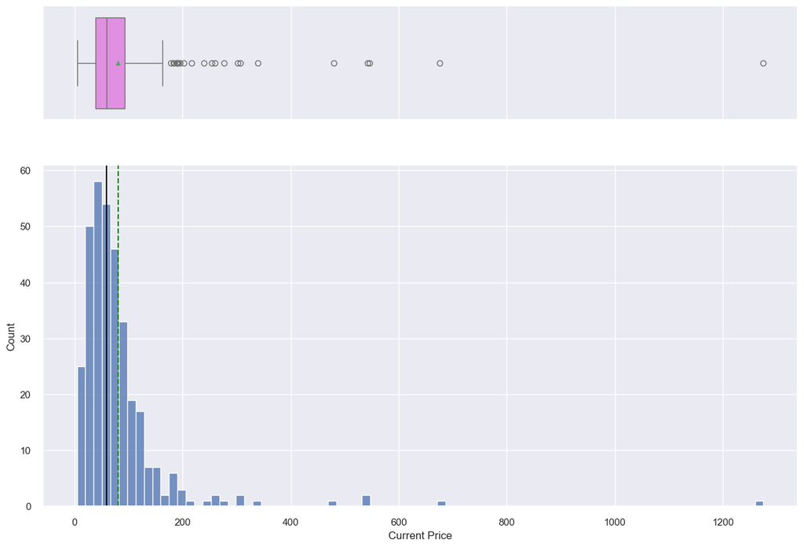

```python
# Calculate statistics and plot a histogram and boxplot.
calculate_statistics (data=df, feature='Current Price')
histogram_boxplot(df, 'Current Price')
```

```python
# Let's take a quick look at some of the maximum outliers
df.loc[df['Current Price']>174.367503]
```

|  | Ticker Symbol | Security | GICS Sector | GICS Sub Industry | Current Price | Price Change | Volatility | ROE | Cash Ratio | Net Cash Flow | Net Income | Earnings Per Share | Estimated Shares Outstanding | P/E Ratio | P/B Ratio |
| --- | --- | --- | --- | --- | --- | --- | --- | --- | --- | --- | --- | --- | --- | --- | --- |
| 6 | ADS | Alliance Data Systems | Information Technology | Data Processing & Outsourced Services | 276.570007 | 6.189286 | 1.116976 | 30 | 25 | 90885000 | 596541000 | 8.91 | 6.695185e+07 | 31.040405 | 129.064585 |
| 19 | ALXN | Alexion Pharmaceuticals | Health Care | Biotechnology | 190.750000 | 22.338380 | 2.022921 | 2 | 195 | 66000000 | 144000000 | 0.68 | 2.117647e+08 | 280.514706 | -14.171389 |
| 26 | AMZN | Amazon.com Inc | Consumer Discretionary | Internet & Direct Marketing Retail | 675.890015 | 32.268105 | 1.460386 | 4 | 58 | 1333000000 | 596000000 | 1.28 | 4.656250e+08 | 528.039074 | 3.904430 |
| 35 | AVB | AvalonBay Communities, Inc. | Real Estate | Residential REITs | 184.130005 | 4.857630 | 1.132875 | 8 | 47 | -108953000 | 741733000 | 5.54 | 1.338868e+08 | 33.236463 | -3.089477 |
| 43 | BCR | Bard (C.R.) Inc. | Health Care | Health Care Equipment | 189.440002 | 1.549182 | 1.394436 | 9 | 82 | -9600000 | 135400000 | 1.80 | 7.522222e+07 | 105.244446 | -4.127770 |
| 45 | BIIB | BIOGEN IDEC Inc. | Health Care | Biotechnology | 306.350006 | 4.917982 | 1.825994 | 38 | 133 | 148900000 | 3547000000 | 15.38 | 2.306242e+08 | 19.918726 | 0.162602 |
| 64 | CHTR | Charter Communications | Consumer Discretionary | Cable & Satellite | 183.100006 | 3.598507 | 1.697942 | 589 | 0 | 2000000 | -271000000 | -2.43 | 1.115226e+08 | 20.819876 | -76.119077 |
| 70 | CMG | Chipotle Mexican Grill | Consumer Discretionary | Restaurants | 479.850006 | -33.131268 | 2.474002 | 22 | 237 | -171460000 | 475602000 | 15.30 | 3.108510e+07 | 31.362745 | 17.201329 |
| 110 | EQIX | Equinix | Real Estate | REITs | 302.399994 | 10.019650 | 1.308082 | 7 | 164 | 1617921000 | 187774000 | 3.25 | 5.777662e+07 | 93.046152 | 23.856728 |
| 114 | ESS | Essex Property Trust, Inc. | Real Estate | Residential REITs | 239.410004 | 6.765073 | 1.118425 | 4 | 47 | 4073000 | 232120000 | 3.50 | 6.632000e+07 | 68.402858 | -3.089477 |
| 146 | GWW | Grainger (W.W.) Inc. | Industrials | Industrial Materials | 202.589996 | -5.336199 | 1.348597 | 34 | 16 | 63492000 | 768996000 | 11.69 | 6.578238e+07 | 17.330196 | 12.112879 |
| 163 | HUM | Humana Inc. | Health Care | Managed Health Care | 178.509995 | -0.145443 | 1.615206 | 12 | 70 | 636000000 | 1276000000 | 8.54 | 1.494145e+08 | 20.902810 | -8.805281 |
| 171 | ISRG | Intuitive Surgical Inc. | Health Care | Health Care Equipment | 546.159973 | 18.733013 | 1.126009 | 14 | 317 | 114300000 | 588800000 | 15.87 | 3.710145e+07 | 34.414617 | 42.607500 |
| 189 | LMT | Lockheed Martin Corp. | Industrials | Aerospace & Defense | 217.149994 | 5.254227 | 0.903098 | 116 | 8 | -356000000 | 3605000000 | 11.62 | 3.102410e+08 | 18.687607 | -10.852854 |
| 205 | MHK | Mohawk Industries | Consumer Discretionary | Home Furnishings | 189.389999 | 3.514425 | 1.492478 | 13 | 3 | -16185000 | 615302000 | 2.59 | 2.375683e+08 | 73.123552 | -3.980316 |
| 218 | MTD | Mettler Toledo | Health Care | Life Sciences Tools & Services | 339.130005 | 18.942905 | 1.115376 | 61 | 18 | 13624000 | 352820000 | 12.75 | 2.767216e+07 | 26.598432 | 4.403994 |
| 237 | ORLY | O'Reilly Automotive | Consumer Discretionary | Specialty Stores | 253.419998 | 0.964143 | 1.089370 | 47 | 4 | -134259000 | 931216000 | 9.32 | 9.991588e+07 | 27.190987 | -0.364026 |
| 243 | PCLN | Priceline.com Inc | Consumer Discretionary | Internet & Direct Marketing Retail | 1274.949951 | 3.190527 | 1.268340 | 29 | 184 | -1671386000 | 2551360000 | 50.09 | 5.093552e+07 | 25.453183 | -1.052429 |
| 264 | REGN | Regeneron | Health Care | Biotechnology | 542.869995 | 16.995320 | 1.802345 | 17 | 129 | 160383000 | 636056000 | 6.17 | 1.030885e+08 | 87.985412 | 20.409000 |
| 266 | ROP | Roper Industries | Industrials | Industrial Conglomerates | 189.789993 | 20.432767 | 1.058807 | 13 | 108 | 168081000 | 696067000 | 6.92 | 1.005877e+08 | 27.426300 | -16.215469 |
| 273 | SHW | Sherwin-Williams | Materials | Specialty Chemicals | 259.600006 | 16.537983 | 1.426488 | 121 | 10 | 165012000 | 1053849000 | 11.38 | 9.260536e+07 | 22.811951 | 2.825366 |
| 277 | SPG | Simon Property Group Inc | Real Estate | REITs | 194.440002 | 5.284822 | 1.135546 | 48 | 47 | 88852000 | 2139375000 | 5.88 | 3.638393e+08 | 33.068028 | -1.269332 |

#### Observations

- Mean: The average current price is approximately $\$80.86$.
- Median: The median current price is $\$59.71$, which is lower than the mean, indicating a positive skew in the distribution.
- Range: The current price values range from a minimum of $\$4.50$ to a maximum of approximately $\$1,274.95$, indicating a substantial spread in stock prices.
- Standard Deviation: The standard deviation is approximately $\$98.06$, which is relatively high compared to the mean, indicating significant variability in the current prices.
- The maximum outliers appear to be valid values in typical high-valued sectors.

```
Discrete Statistics for Price Change

Mean              : 4.078194
Mode              : -47.12969338
Median            : 4.819504729
Min               : -47.12969338
Max               : 55.05168339
Standard Deviation: 12.006338
Percentiles       :
0.25    -0.939484
0.50     4.819505
0.75    10.695493
Name: Price Change, dtype: float64
Minimum Whisker     : -18.391948
Maximum Whisker     : 28.147957
```

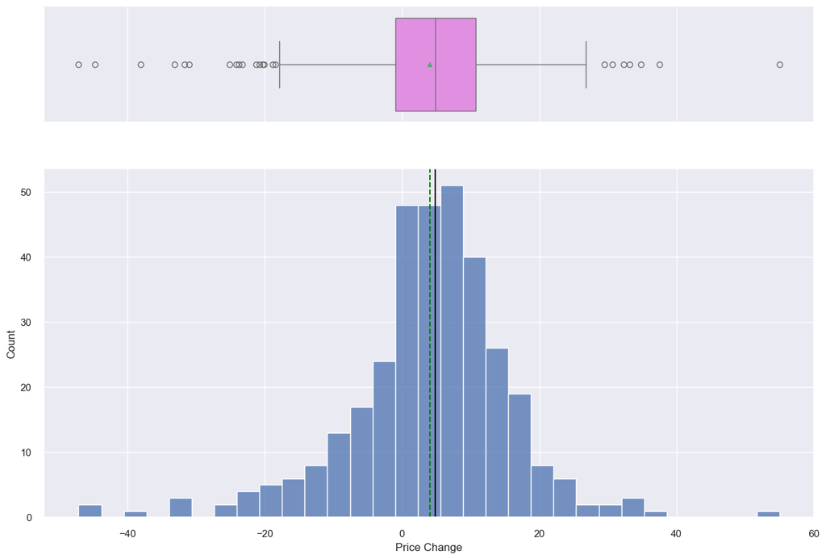

```python
# Calculate statistics and plot a histogram and boxplot.
calculate_statistics (data=df, feature='Price Change')
histogram_boxplot(df, 'Price Change')
```

```python
# Let's take a quick look at some of the minimum and maximum outliers
df.loc[(df['Price Change']<-18.391948) | (df['Price Change']>28.147957)]
```

|  | Ticker Symbol | Security | GICS Sector | GICS Sub Industry | Current Price | Price Change | Volatility | ROE | Cash Ratio | Net Cash Flow | Net Income | Earnings Per Share | Estimated Shares Outstanding | P/E Ratio | P/B Ratio |
| --- | --- | --- | --- | --- | --- | --- | --- | --- | --- | --- | --- | --- | --- | --- | --- |
| 14 | AKAM | Akamai Technologies Inc | Information Technology | Internet Software & Services | 52.630001 | -23.790903 | 1.384502 | 10 | 225 | 50823000 | 321406000 | 1.80 | 1.785589e+08 | 29.238889 | 4.282358 |
| 26 | AMZN | Amazon.com Inc | Consumer Discretionary | Internet & Direct Marketing Retail | 675.890015 | 32.268105 | 1.460386 | 4 | 58 | 1333000000 | 596000000 | 1.28 | 4.656250e+08 | 528.039074 | 3.904430 |
| 31 | APC | Anadarko Petroleum Corp | Energy | Oil & Gas Exploration & Production | 48.580002 | -20.802083 | 2.435165 | 52 | 22 | -6430000000 | -6692000000 | -13.18 | 5.077390e+08 | 93.089287 | -12.860938 |
| 62 | CHK | Chesapeake Energy | Energy | Integrated Oil & Gas | 4.500000 | -38.101788 | 4.559815 | 687 | 22 | -3283000000 | -14685000000 | -22.43 | 6.547035e+08 | 28.407929 | -1.840528 |
| 70 | CMG | Chipotle Mexican Grill | Consumer Discretionary | Restaurants | 479.850006 | -33.131268 | 2.474002 | 22 | 237 | -171460000 | 475602000 | 15.30 | 3.108510e+07 | 31.362745 | 17.201329 |
| 71 | CMI | Cummins Inc. | Industrials | Industrial Machinery | 88.010002 | -18.884791 | 1.472364 | 19 | 48 | -590000000 | 1399000000 | 7.86 | 1.779898e+08 | 11.197201 | 21.439428 |
| 76 | COG | Cabot Oil & Gas | Energy | Oil & Gas Exploration & Production | 17.690001 | -20.099360 | 3.055818 | 6 | 0 | -20440000 | -113891000 | -0.28 | 4.067536e+08 | 93.089287 | -0.223147 |
| 87 | DD | Du Pont (E.I.) | Materials | Diversified Chemicals | 66.599998 | 37.489677 | 1.577881 | 20 | 60 | -1610000000 | 1953000000 | 2.17 | 9.000000e+08 | 30.691243 | 3.252222 |
| 112 | EQT | EQT Corporation | Energy | Oil & Gas Exploration & Production | 52.130001 | -21.253771 | 2.364883 | 2 | 201 | 523803000 | 85171000 | 0.56 | 1.520911e+08 | 93.089287 | 9.567952 |
| 127 | FCX | Freeport-McMoran Cp & Gld | Materials | Copper | 6.770000 | -31.685167 | 3.796410 | 155 | 5 | -240000000 | -12156000000 | -11.31 | 1.074801e+09 | 22.811951 | 2.935427 |
| 136 | FSLR | First Solar Inc | Information Technology | Semiconductors | 65.989998 | 55.051683 | 2.075216 | 10 | 190 | -355228000 | 546421000 | 5.42 | 1.008157e+08 | 12.175276 | 22.563791 |
| 180 | KMI | Kinder Morgan | Energy | Oil & Gas Refining & Marketing & Transportation | 14.920000 | -47.129693 | 3.139352 | 1 | 7 | -86000000 | 253000000 | 0.10 | 2.530000e+09 | 149.200000 | -1.894071 |
| 182 | KSU | Kansas City Southern | Industrials | Railroads | 74.669998 | -18.438017 | 2.071639 | 12 | 18 | -211400000 | 483500000 | 4.41 | 1.096372e+08 | 16.931972 | -2.012091 |
| 200 | MAT | Mattel Inc. | Consumer Discretionary | Leisure Products | 27.170000 | 30.625006 | 1.921708 | 14 | 54 | -78836000 | 369416000 | 1.08 | 3.420519e+08 | 25.157407 | 4.535251 |
| 216 | MRO | Marathon Oil Corp. | Energy | Oil & Gas Exploration & Production | 12.590000 | -20.265991 | 3.325386 | 12 | 71 | -1177000000 | -2204000000 | -3.26 | 6.760736e+08 | 93.089287 | 1.273530 |
| 220 | MYL | Mylan N.V. | Health Care | Pharmaceuticals | 54.070000 | 33.177346 | 2.299304 | 9 | 30 | 1010500000 | 847600000 | 1.58 | 1.633016e+09 | 33.430380 | -4.213309 |
| 235 | OKE | ONEOK | Energy | Oil & Gas Exploration & Production | 24.660000 | -24.123077 | 3.560178 | 73 | 6 | -75150000 | 244977000 | 1.17 | 2.093821e+08 | 21.076923 | -8.025110 |
| 262 | R | Ryder System | Industrials | Industrial Conglomerates | 56.830002 | -23.244191 | 1.945966 | 15 | 4 | 10853000 | 304768000 | 5.75 | 5.300313e+07 | 9.883479 | -12.020894 |
| 267 | RRC | Range Resources Corp. | Energy | Oil & Gas Exploration & Production | 24.610001 | -25.106512 | 3.712995 | 26 | 0 | 23000 | -713685000 | -4.29 | 1.663601e+08 | 93.089287 | 0.525090 |
| 284 | SWN | Southwestern Energy | Energy | Oil & Gas Exploration & Production | 7.110000 | -44.798137 | 4.580042 | 200 | 2 | -38000000 | -4556000000 | -6.07 | 4.021417e+08 | 93.089287 | 1.273530 |
| 293 | TRIP | TripAdvisor | Consumer Discretionary | Internet & Direct Marketing Retail | 85.250000 | 34.803917 | 1.578344 | 14 | 212 | 159000000 | 198000000 | 1.38 | 1.434783e+08 | 61.775362 | 2.627576 |
| 323 | WMB | Williams Cos. | Energy | Oil & Gas Exploration & Production | 25.700001 | -30.988186 | 3.719560 | 9 | 4 | -140000000 | -571000000 | -0.76 | 7.513158e+08 | 93.089287 | -14.561121 |
| 327 | WYNN | Wynn Resorts Ltd | Consumer Discretionary | Casinos & Gaming | 69.190002 | 29.496541 | 3.794783 | 174 | 198 | -102075000 | 195290000 | 1.93 | 1.011865e+08 | 35.849742 | 12.695712 |

```
Discrete Statistics for Volatility

Mean              : 1.525976
Mode              : 0.733163184
Median            : 1.3855929255000001
Min               : 0.733163184
Max               : 4.58004173
Standard Deviation: 0.591798
Percentiles       :
0.25    1.134878
0.50    1.385593
0.75    1.695549
Name: Volatility, dtype: float64
Minimum Whisker     : 0.733163
Maximum Whisker     : 2.536555
```

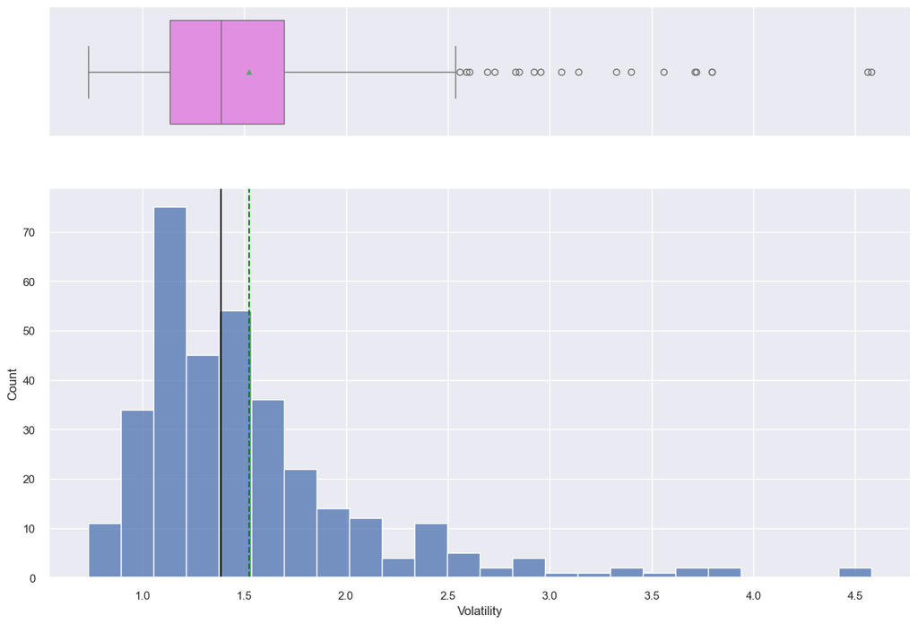

```python
# Calculate statistics and plot a histogram and boxplot.
calculate_statistics (data=df, feature='Volatility')
histogram_boxplot(df, 'Volatility')
```

```python
# Let's take a quick look at some of the maximum outliers
df.loc[df['Volatility']>2.536555]
```

|  | Ticker Symbol | Security | GICS Sector | GICS Sub Industry | Current Price | Price Change | Volatility | ROE | Cash Ratio | Net Cash Flow | Net Income | Earnings Per Share | Estimated Shares Outstanding | P/E Ratio | P/B Ratio |
| --- | --- | --- | --- | --- | --- | --- | --- | --- | --- | --- | --- | --- | --- | --- | --- |
| 33 | ARNC | Arconic Inc | Industrials | Aerospace & Defense | 7.398807 | 1.647784 | 2.592065 | 3 | 37 | 42000000 | -322000000 | -0.31 | 1.038710e+09 | 18.687607 | 2.639814 |
| 44 | BHI | Baker Hughes Inc | Energy | Oil & Gas Equipment & Services | 46.150002 | -12.312367 | 2.559553 | 12 | 84 | 584000000 | -1967000000 | -4.49 | 4.380846e+08 | 93.089287 | 13.490544 |
| 62 | CHK | Chesapeake Energy | Energy | Integrated Oil & Gas | 4.500000 | -38.101788 | 4.559815 | 687 | 22 | -3283000000 | -14685000000 | -22.43 | 6.547035e+08 | 28.407929 | -1.840528 |
| 76 | COG | Cabot Oil & Gas | Energy | Oil & Gas Exploration & Production | 17.690001 | -20.099360 | 3.055818 | 6 | 0 | -20440000 | -113891000 | -0.28 | 4.067536e+08 | 93.089287 | -0.223147 |
| 84 | CXO | Concho Resources | Energy | Oil & Gas Exploration & Production | 92.860001 | -2.744032 | 2.692546 | 1 | 38 | 228529000 | 65900000 | 0.54 | 1.220370e+08 | 171.962965 | 5.673991 |
| 102 | DVN | Devon Energy Corp. | Energy | Oil & Gas Exploration & Production | 32.000000 | -15.478079 | 2.923698 | 205 | 70 | 830000000 | -14454000000 | -35.55 | 4.065823e+08 | 93.089287 | 1.785616 |
| 127 | FCX | Freeport-McMoran Cp & Gld | Materials | Copper | 6.770000 | -31.685167 | 3.796410 | 155 | 5 | -240000000 | -12156000000 | -11.31 | 1.074801e+09 | 22.811951 | 2.935427 |
| 157 | HPE | Hewlett Packard Enterprise | Information Technology | Technology Hardware, Storage & Peripherals | 15.200000 | -17.837838 | 3.400491 | 7 | 45 | 7523000000 | 2461000000 | 1.80 | 5.139877e+08 | 25.309524 | 3.954975 |
| 180 | KMI | Kinder Morgan | Energy | Oil & Gas Refining & Marketing & Transportation | 14.920000 | -47.129693 | 3.139352 | 1 | 7 | -86000000 | 253000000 | 0.10 | 2.530000e+09 | 149.200000 | -1.894071 |
| 213 | MOS | The Mosaic Company | Materials | Fertilizers & Agricultural Chemicals | 27.590000 | -11.229086 | 2.830675 | 10 | 62 | -1098300000 | 1000400000 | 2.79 | 3.585663e+08 | 9.888889 | 5.846617 |
| 216 | MRO | Marathon Oil Corp. | Energy | Oil & Gas Exploration & Production | 12.590000 | -20.265991 | 3.325386 | 12 | 71 | -1177000000 | -2204000000 | -3.26 | 6.760736e+08 | 93.089287 | 1.273530 |
| 219 | MUR | Murphy Oil | Energy | Integrated Oil & Gas | 22.450001 | -8.591197 | 2.851180 | 43 | 27 | -910125000 | -2270833000 | -13.03 | 1.742773e+08 | 28.407929 | -1.298006 |
| 226 | NFLX | Netflix Inc. | Information Technology | Internet Software & Services | 114.379997 | 11.145654 | 2.605949 | 6 | 65 | 695722000 | 122641000 | 0.29 | 4.229000e+08 | 394.413783 | -5.700168 |
| 235 | OKE | ONEOK | Energy | Oil & Gas Exploration & Production | 24.660000 | -24.123077 | 3.560178 | 73 | 6 | -75150000 | 244977000 | 1.17 | 2.093821e+08 | 21.076923 | -8.025110 |
| 259 | PWR | Quanta Services Inc. | Industrials | Industrial Conglomerates | 20.250000 | -16.632362 | 2.954291 | 10 | 11 | -61744000 | 321824000 | 1.59 | 2.024050e+08 | 12.735849 | 4.291894 |
| 267 | RRC | Range Resources Corp. | Energy | Oil & Gas Exploration & Production | 24.610001 | -25.106512 | 3.712995 | 26 | 0 | 23000 | -713685000 | -4.29 | 1.663601e+08 | 93.089287 | 0.525090 |
| 284 | SWN | Southwestern Energy | Energy | Oil & Gas Exploration & Production | 7.110000 | -44.798137 | 4.580042 | 200 | 2 | -38000000 | -4556000000 | -6.07 | 4.021417e+08 | 93.089287 | 1.273530 |
| 289 | TDC | Teradata Corp. | Information Technology | Application Software | 26.420000 | -8.833678 | 2.730659 | 25 | 88 | 5000000 | -214000000 | -1.53 | 1.398693e+08 | 74.555557 | 4.068084 |
| 323 | WMB | Williams Cos. | Energy | Oil & Gas Exploration & Production | 25.700001 | -30.988186 | 3.719560 | 9 | 4 | -140000000 | -571000000 | -0.76 | 7.513158e+08 | 93.089287 | -14.561121 |
| 327 | WYNN | Wynn Resorts Ltd | Consumer Discretionary | Casinos & Gaming | 69.190002 | 29.496541 | 3.794783 | 174 | 198 | -102075000 | 195290000 | 1.93 | 1.011865e+08 | 35.849742 | 12.695712 |

#### Observations

- Mean: The average volatility is approximately $\$1.53$.
- Median: The median volatility is approximately $\$1.39$, which is slightly lower than the mean, indicating a slight positive skew in the distribution.
- Range: The volatility values range from a minimum of approximately $\$0.73$ to a maximum of approximately $\$4.58$, indicating a moderate spread in volatility levels.
- Standard Deviation: The standard deviation is approximately $\$0.59$, which is relatively moderate compared to the mean, suggesting some variability in volatility levels.
- The mean ($\$1.53$) being slightly higher than the median ($\$1.39$) suggests a slight positive skew in the data.
- The maximum outliers are normal in nature.

```
Discrete Statistics for ROE

Mean              : 39.597059
Mode              : 10
Median            : 15.0
Min               : 1
Max               : 917
Standard Deviation: 96.547538
Percentiles       :
0.25     9.75
0.50    15.00
0.75    27.00
Name: ROE, dtype: float64
Minimum Whisker     : 1.000000
Maximum Whisker     : 52.875000
```

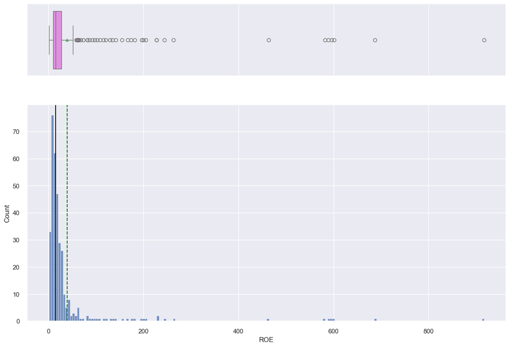

```python
# Calculate statistics and plot a histogram and boxplot.
calculate_statistics (data=df, feature='ROE')
histogram_boxplot(df, 'ROE')
```

```python
# Let's take a quick look at some of the maximum outliers
df.loc[df['ROE']> 52.875000]
```

|  | Ticker Symbol | Security | GICS Sector | GICS Sub Industry | Current Price | Price Change | Volatility | ROE | Cash Ratio | Net Cash Flow | Net Income | Earnings Per Share | Estimated Shares Outstanding | P/E Ratio | P/B Ratio |
| --- | --- | --- | --- | --- | --- | --- | --- | --- | --- | --- | --- | --- | --- | --- | --- |
| 0 | AAL | American Airlines Group | Industrials | Airlines | 42.349998 | 9.999995 | 1.687151 | 135 | 51 | -604000000 | 7610000000 | 11.39 | 6.681299e+08 | 3.718174 | -8.784219 |
| 1 | ABBV | AbbVie | Health Care | Pharmaceuticals | 59.240002 | 8.339433 | 2.197887 | 130 | 77 | 51000000 | 5144000000 | 3.15 | 1.633016e+09 | 18.806350 | -8.750068 |
| 18 | ALLE | Allegion | Industrials | Building Products | 65.919998 | 13.753230 | 1.283795 | 601 | 45 | -90800000 | 153900000 | 1.60 | 9.618750e+07 | 41.199999 | -0.877453 |
| 30 | APA | Apache Corporation | Energy | Oil & Gas Exploration & Production | 44.470001 | 11.397804 | 2.405408 | 917 | 80 | 698000000 | -23528000000 | -61.20 | 3.844444e+08 | 93.089287 | 4.970809 |
| 39 | BA | Boeing Company | Industrials | Aerospace & Defense | 144.589996 | 10.105078 | 1.155905 | 82 | 24 | -431000000 | 5176000000 | 7.52 | 6.882979e+08 | 19.227393 | 22.032612 |
| 62 | CHK | Chesapeake Energy | Energy | Integrated Oil & Gas | 4.500000 | -38.101788 | 4.559815 | 687 | 22 | -3283000000 | -14685000000 | -22.43 | 6.547035e+08 | 28.407929 | -1.840528 |
| 64 | CHTR | Charter Communications | Consumer Discretionary | Cable & Satellite | 183.100006 | 3.598507 | 1.697942 | 589 | 0 | 2000000 | -271000000 | -2.43 | 1.115226e+08 | 20.819876 | -76.119077 |
| 67 | CL | Colgate-Palmolive | Consumer Staples | Household Products | 66.620003 | 4.781379 | 0.895471 | 463 | 27 | -119000000 | 1384000000 | 1.53 | 9.045752e+08 | 43.542486 | -0.548324 |
| 95 | DLPH | Delphi Automotive | Consumer Discretionary | Auto Parts & Equipment | 85.730003 | 12.109326 | 1.440884 | 64 | 14 | -325000000 | 1450000000 | 5.08 | 2.854331e+08 | 16.875985 | -0.662152 |
| 102 | DVN | Devon Energy Corp. | Energy | Oil & Gas Exploration & Production | 32.000000 | -15.478079 | 2.923698 | 205 | 70 | 830000000 | -14454000000 | -35.55 | 4.065823e+08 | 93.089287 | 1.785616 |
| 127 | FCX | Freeport-McMoran Cp & Gld | Materials | Copper | 6.770000 | -31.685167 | 3.796410 | 155 | 5 | -240000000 | -12156000000 | -11.31 | 1.074801e+09 | 22.811951 | 2.935427 |
| 140 | GILD | Gilead Sciences | Health Care | Biotechnology | 101.190002 | 2.689264 | 1.494060 | 98 | 148 | 2824000000 | 18108000000 | 12.37 | 1.463864e+09 | 8.180275 | 3.159446 |
| 164 | IBM | International Business Machines | Information Technology | IT Consulting & Other Services | 137.619995 | -5.292136 | 1.082881 | 92 | 24 | -790000000 | 13190000000 | 13.48 | 9.784866e+08 | 10.209198 | 4.852391 |
| 165 | IDXX | IDEXX Laboratories | Health Care | Health Care Equipment | 72.919998 | -1.565880 | 1.469586 | 228 | 40 | -193542000 | 192078000 | 2.07 | 9.279130e+07 | 35.227052 | -0.981083 |
| 179 | KMB | Kimberly-Clark | Consumer Staples | Household Products | 127.300003 | 17.511309 | 0.870405 | 582 | 10 | -170000000 | 1013000000 | 2.78 | 3.643885e+08 | 45.791368 | -2.533011 |
| 189 | LMT | Lockheed Martin Corp. | Industrials | Aerospace & Defense | 217.149994 | 5.254227 | 0.903098 | 116 | 8 | -356000000 | 3605000000 | 11.62 | 3.102410e+08 | 18.687607 | -10.852854 |
| 194 | LYB | LyondellBasell | Materials | Diversified Chemicals | 86.900002 | 2.573183 | 1.609745 | 68 | 46 | -107000000 | 4476000000 | 9.62 | 4.652807e+08 | 9.033264 | 10.316354 |
| 195 | MA | Mastercard Inc. | Information Technology | Internet Software & Services | 97.360001 | 7.496965 | 1.095876 | 63 | 130 | 610000000 | 3808000000 | 3.36 | 1.133333e+09 | 28.976191 | 3.451765 |
| 199 | MAS | Masco Corp. | Industrials | Building Products | 28.299999 | 11.637077 | 1.428359 | 263 | 61 | 85000000 | 355000000 | 1.03 | 3.446602e+08 | 27.475727 | 2.219577 |
| 201 | MCD | McDonald's Corp. | Consumer Discretionary | Restaurants | 118.139999 | 19.939085 | 0.733163 | 64 | 260 | 5607600000 | 4529300000 | 4.82 | 9.396888e+08 | 24.510373 | 7.122145 |
| 202 | MCO | Moody's Corp | Financials | Diversified Financial Services | 100.339996 | 2.345976 | 1.268800 | 167 | 183 | 537900000 | 941300000 | 4.70 | 2.002766e+08 | 21.348935 | 8.615585 |
| 206 | MJN | Mead Johnson | Consumer Staples | Packaged Foods & Meats | 78.949997 | 12.081196 | 1.718403 | 103 | 136 | 403700000 | 653500000 | 3.28 | 1.992378e+08 | 24.070121 | 6.495755 |
| 212 | MO | Altria Group Inc | Consumer Staples | Tobacco | 58.209999 | 6.885788 | 0.959008 | 182 | 33 | -952000000 | 5241000000 | 2.67 | 1.962921e+09 | 21.801498 | -6.632971 |
| 218 | MTD | Mettler Toledo | Health Care | Life Sciences Tools & Services | 339.130005 | 18.942905 | 1.115376 | 61 | 18 | 13624000 | 352820000 | 12.75 | 2.767216e+07 | 26.598432 | 4.403994 |
| 227 | NFX | Newfield Exploration Co | Energy | Oil & Gas Exploration & Production | 32.560001 | -3.296695 | 2.421529 | 244 | 1 | -9000000 | -3362000000 | -21.18 | 1.587347e+08 | 93.089287 | -0.138596 |
| 235 | OKE | ONEOK | Energy | Oil & Gas Exploration & Production | 24.660000 | -24.123077 | 3.560178 | 73 | 6 | -75150000 | 244977000 | 1.17 | 2.093821e+08 | 21.076923 | -8.025110 |
| 240 | PBI | Pitney-Bowes | Industrials | Technology, Hardware, Software and Supplies | 20.650000 | 3.821021 | 1.259611 | 228 | 34 | -403561000 | 407943000 | 2.04 | 1.999721e+08 | 10.122549 | -0.733207 |
| 273 | SHW | Sherwin-Williams | Materials | Specialty Chemicals | 259.600006 | 16.537983 | 1.426488 | 121 | 10 | 165012000 | 1053849000 | 11.38 | 9.260536e+07 | 22.811951 | 2.825366 |
| 278 | SPGI | S&P Global, Inc. | Financials | Diversified Financial Services | 98.580002 | 14.044424 | 1.080858 | 596 | 51 | -1016000000 | 1156000000 | 4.26 | 2.713615e+08 | 23.140846 | -4.178927 |
| 284 | SWN | Southwestern Energy | Energy | Oil & Gas Exploration & Production | 7.110000 | -44.798137 | 4.580042 | 200 | 2 | -38000000 | -4556000000 | -6.07 | 4.021417e+08 | 93.089287 | 1.273530 |
| 301 | UAL | United Continental Holdings | Industrials | Airlines | 57.299999 | 8.215294 | 1.747606 | 82 | 42 | 1004000000 | 7340000000 | 19.52 | 3.760246e+08 | 2.935451 | -23.195292 |
| 307 | UPS | United Parcel Service | Industrials | Air Freight & Logistics | 96.230003 | -2.797977 | 0.826408 | 196 | 44 | 439000000 | 4844000000 | 5.38 | 9.003717e+08 | 17.886618 | 1.069558 |
| 315 | VRTX | Vertex Pharmaceuticals Inc | Health Care | Biotechnology | 125.830002 | 21.928300 | 2.456535 | 59 | 221 | 89509000 | -556334000 | -2.31 | 2.408372e+08 | 39.602928 | 2.559671 |
| 317 | VZ | Verizon Communications | Telecommunications Services | Integrated Telecommunications Services | 46.220001 | 6.277303 | 0.842592 | 109 | 14 | -6128000000 | 17879000000 | 4.38 | 4.081963e+09 | 10.552512 | -26.380687 |
| 324 | WU | Western Union Co | Information Technology | Internet Software & Services | 17.910000 | -2.610109 | 1.273051 | 60 | 16 | -467300000 | 837800000 | 1.63 | 5.139877e+08 | 10.987730 | -8.043772 |
| 326 | WYN | Wyndham Worldwide | Consumer Discretionary | Hotels, Resorts & Cruise Lines | 72.650002 | 1.000976 | 1.331918 | 64 | 9 | -12000000 | 612000000 | 5.18 | 1.181467e+08 | 14.025097 | -10.249967 |
| 327 | WYNN | Wynn Resorts Ltd | Consumer Discretionary | Casinos & Gaming | 69.190002 | 29.496541 | 3.794783 | 174 | 198 | -102075000 | 195290000 | 1.93 | 1.011865e+08 | 35.849742 | 12.695712 |
| 328 | XEC | Cimarex Energy | Energy | Oil & Gas Exploration & Production | 89.379997 | -14.403372 | 2.397940 | 86 | 190 | 373520000 | -2408948000 | -25.92 | 9.293781e+07 | 93.089287 | 7.186128 |
| 336 | YUM | Yum! Brands Inc | Consumer Discretionary | Restaurants | 52.516175 | -8.698917 | 1.478877 | 142 | 27 | 159000000 | 1293000000 | 2.97 | 4.353535e+08 | 17.682214 | -3.838260 |

#### Observations

- Mean: The average Return on Equity is approximately 39.60%.
- Median: The median Return on Equity is 15.00%, indicating that the distribution is positively skewed due to potentially higher values.
- Range: Return on Equity values range from a minimum of 1% to a maximum of 917%. The presence of a high maximum suggests significant variation across different companies.
- Standard Deviation: The standard deviation is relatively high at approximately 96.55%, indicating wide variability in Return on Equity among the dataset.
- The mean (39.60%) is higher than the median (15.00%), suggesting a positively skewed distribution. This indicates that while most companies have moderate Return on Equity, there are some companies with exceptionally high returns that pull the mean upwards.
- The maximum outliers are normal in nature.

```
Discrete Statistics for Cash Ratio

Mean              : 70.023529
Mode              : 99
Median            : 47.0
Min               : 0
Max               : 958
Standard Deviation: 90.421331
Percentiles       :
0.25    18.0
0.50    47.0
0.75    99.0
Name: Cash Ratio, dtype: float64
Minimum Whisker     : 0.000000
Maximum Whisker     : 220.500000
```

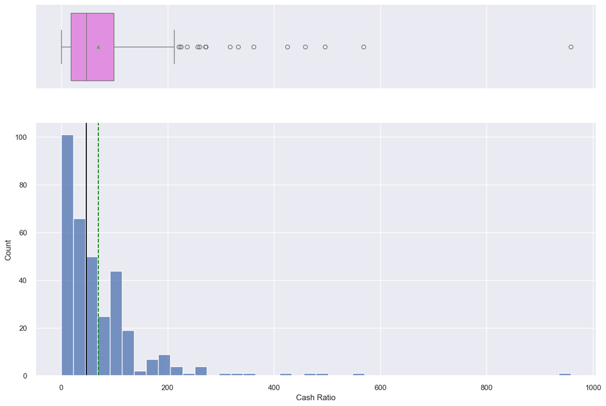

```python
# Calculate statistics and plot a histogram and boxplot.
calculate_statistics (data=df, feature='Cash Ratio')
histogram_boxplot(df, 'Cash Ratio')
```

```python
# Let's take a quick look at some of the maximum outliers
df.loc[df['Cash Ratio']> 220.500000]
```

|  | Ticker Symbol | Security | GICS Sector | GICS Sub Industry | Current Price | Price Change | Volatility | ROE | Cash Ratio | Net Cash Flow | Net Income | Earnings Per Share | Estimated Shares Outstanding | P/E Ratio | P/B Ratio |
| --- | --- | --- | --- | --- | --- | --- | --- | --- | --- | --- | --- | --- | --- | --- | --- |
| 4 | ADI | Analog Devices, Inc. | Information Technology | Semiconductors | 55.320000 | -1.827858 | 1.701169 | 14 | 272 | 315120000 | 696878000 | 0.31 | 2.247994e+09 | 178.451613 | 1.059810 |
| 14 | AKAM | Akamai Technologies Inc | Information Technology | Internet Software & Services | 52.630001 | -23.790903 | 1.384502 | 10 | 225 | 50823000 | 321406000 | 1.80 | 1.785589e+08 | 29.238889 | 4.282358 |
| 23 | AMGN | Amgen Inc | Health Care | Biotechnology | 162.330002 | 17.163478 | 1.630259 | 25 | 362 | 413000000 | 6939000000 | 9.15 | 7.583607e+08 | 17.740984 | 24.012322 |
| 58 | CELG | Celgene Corp. | Health Care | Biotechnology | 119.760002 | 8.448793 | 2.000828 | 27 | 333 | 758700000 | 1602000000 | 2.02 | 7.930693e+08 | 59.287130 | -4.320051 |
| 70 | CMG | Chipotle Mexican Grill | Consumer Discretionary | Restaurants | 479.850006 | -33.131268 | 2.474002 | 22 | 237 | -171460000 | 475602000 | 15.30 | 3.108510e+07 | 31.362745 | 17.201329 |
| 103 | EBAY | eBay Inc. | Information Technology | Internet Software & Services | 27.480000 | 12.163265 | 1.409302 | 26 | 271 | -4496000000 | 1725000000 | 1.43 | 1.206294e+09 | 19.216783 | 4.601699 |
| 118 | EW | Edwards Lifesciences | Health Care | Health Care Equipment | 78.980003 | 11.616734 | 1.666482 | 20 | 257 | 64600000 | 494900000 | 2.30 | 2.151739e+08 | 34.339132 | 6.349747 |
| 125 | FB | Facebook | Information Technology | Internet Software & Services | 104.660004 | 16.224320 | 1.320606 | 8 | 958 | 592000000 | 3669000000 | 1.31 | 2.800763e+09 | 79.893133 | 5.884467 |
| 137 | FTR | Frontier Communications | Telecommunications Services | Integrated Telecommunications Services | 4.670000 | -2.301255 | 2.026818 | 3 | 496 | 254000000 | -196000000 | -0.29 | 6.758621e+08 | 14.518987 | 10.497704 |
| 171 | ISRG | Intuitive Surgical Inc. | Health Care | Health Care Equipment | 546.159973 | 18.733013 | 1.126009 | 14 | 317 | 114300000 | 588800000 | 15.87 | 3.710145e+07 | 34.414617 | 42.607500 |
| 201 | MCD | McDonald's Corp. | Consumer Discretionary | Restaurants | 118.139999 | 19.939085 | 0.733163 | 64 | 260 | 5607600000 | 4529300000 | 4.82 | 9.396888e+08 | 24.510373 | 7.122145 |
| 211 | MNST | Monster Beverage | Consumer Staples | Soft Drinks | 49.653332 | 10.800357 | 1.585944 | 11 | 568 | 1805094000 | 546733000 | 3.71 | 1.469542e+09 | 25.420118 | -5.190734 |
| 283 | SWKS | Skyworks Solutions | Information Technology | Semiconductors | 76.830002 | -8.513933 | 2.017394 | 25 | 225 | 237800000 | 798300000 | 4.21 | 1.896200e+08 | 18.249407 | 7.413777 |
| 315 | VRTX | Vertex Pharmaceuticals Inc | Health Care | Biotechnology | 125.830002 | 21.928300 | 2.456535 | 59 | 221 | 89509000 | -556334000 | -2.31 | 2.408372e+08 | 39.602928 | 2.559671 |
| 318 | WAT | Waters Corporation | Health Care | Health Care Distributors | 134.580002 | 13.925341 | 1.044615 | 23 | 425 | 65488000 | 469053000 | 5.70 | 8.229000e+07 | 23.610527 | 29.547150 |
| 335 | YHOO | Yahoo Inc. | Information Technology | Internet Software & Services | 33.259998 | 14.887727 | 1.845149 | 15 | 459 | -1032187000 | -4359082000 | -4.64 | 9.394573e+08 | 28.976191 | 6.261775 |

#### Observations

- Mean: The average Cash Ratio is approximately 70.02.
- Median: The median Cash Ratio is 47.0, indicating a positively skewed distribution.
- Range: Cash Ratio values range from a minimum of 0 to a maximum of 958. This wide range suggests significant variation in the liquidity position of companies.
- Standard Deviation: The standard deviation is relatively high at approximately 90.42, indicating substantial variability in Cash Ratios among the dataset.
- The maximum outliers are normal in nature.

```
Discrete Statistics for Net Cash Flow

Mean              : 55537620.588235
Mode              : -34000000
Median            : 2098000.0
Min               : -11208000000
Max               : 20764000000
Standard Deviation: 1946365312.175789
Percentiles       :
0.25   -193906500.0
0.50      2098000.0
0.75    169810750.0
Name: Net Cash Flow, dtype: float64
Minimum Whisker     : -739482375.000000
Maximum Whisker     : 715386625.000000
```

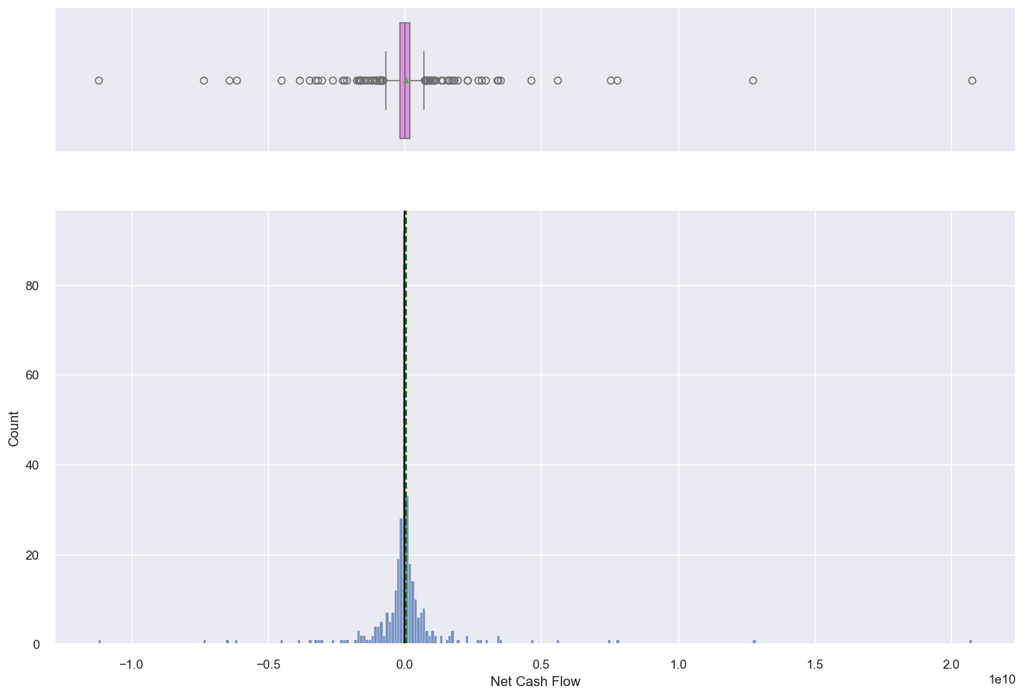

```python
# Calculate statistics and plot a histogram and boxplot.
calculate_statistics (data=df, feature='Net Cash Flow')
histogram_boxplot(df, 'Net Cash Flow')
```

#### Observations

- Mean: The average Net Cash Flow is approximately $\$55,537,620$.
- Median: The median Net Cash Flow is $\$2,098,000$.
- Range: Net Cash Flow values range from a minimum of $\$-11,208,000,000$ to a maximum of $\$20,764,000,000$. The wide range indicates significant variation in cash flow positions among companies.
- Standard Deviation: The standard deviation is approximately $\$1,946,365,312$, indicating substantial variability in Net Cash Flow among the dataset.
- The distribution of Net Cash Flow is slightly skewed to the right (positive skew), as evidenced by the mean being greater than the median.
- The minimum and maximum outliers are normal in nature.

```
Discrete Statistics for Net Income

Mean              : 1494384602.941176
Mode              : 355000000
Median            : 707336000.0
Min               : -23528000000
Max               : 24442000000
Standard Deviation: 3940150279.327937
Percentiles       :
0.25    3.523012e+08
0.50    7.073360e+08
0.75    1.899000e+09
Name: Net Income, dtype: float64
Minimum Whisker     : -1967746875.000000
Maximum Whisker     : 4219048125.000000
```

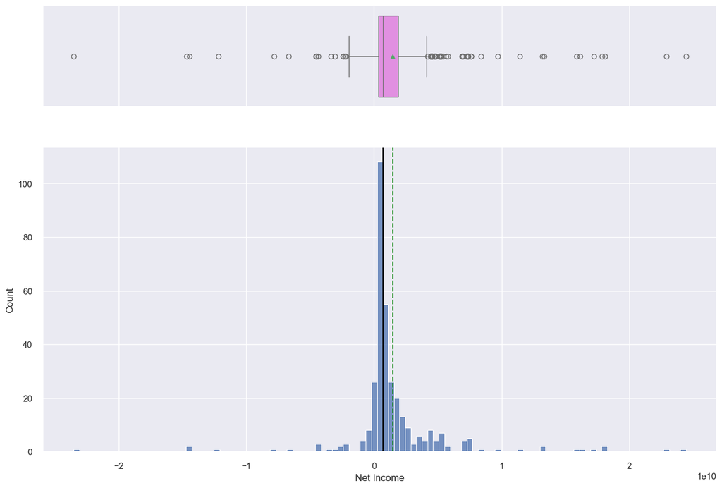

```python
# Calculate statistics and plot a histogram and boxplot.
calculate_statistics (data=df, feature='Net Income')
histogram_boxplot(df, 'Net Income')
```

```python
# Let's take a quick look at some of the maximum outliers
df.loc[df['Net Income']> 4219048125.0]
```

|  | Ticker Symbol | Security | GICS Sector | GICS Sub Industry | Current Price | Price Change | Volatility | ROE | Cash Ratio | Net Cash Flow | Net Income | Earnings Per Share | Estimated Shares Outstanding | P/E Ratio | P/B Ratio |
| --- | --- | --- | --- | --- | --- | --- | --- | --- | --- | --- | --- | --- | --- | --- | --- |
| 0 | AAL | American Airlines Group | Industrials | Airlines | 42.349998 | 9.999995 | 1.687151 | 135 | 51 | -604000000 | 7610000000 | 11.39 | 6.681299e+08 | 3.718174 | -8.784219 |
| 1 | ABBV | AbbVie | Health Care | Pharmaceuticals | 59.240002 | 8.339433 | 2.197887 | 130 | 77 | 51000000 | 5144000000 | 3.15 | 1.633016e+09 | 18.806350 | -8.750068 |
| 2 | ABT | Abbott Laboratories | Health Care | Health Care Equipment | 44.910000 | 11.301121 | 1.273646 | 21 | 67 | 938000000 | 4423000000 | 2.94 | 1.504422e+09 | 15.275510 | -0.394171 |
| 23 | AMGN | Amgen Inc | Health Care | Biotechnology | 162.330002 | 17.163478 | 1.630259 | 25 | 362 | 413000000 | 6939000000 | 9.15 | 7.583607e+08 | 17.740984 | 24.012322 |
| 38 | AXP | American Express Co | Financials | Consumer Finance | 69.550003 | -6.216290 | 0.900066 | 25 | 99 | 474000000 | 5163000000 | 3.90 | 5.066604e+08 | 10.263506 | -0.609074 |
| 39 | BA | Boeing Company | Industrials | Aerospace & Defense | 144.589996 | 10.105078 | 1.155905 | 82 | 24 | -431000000 | 5176000000 | 7.52 | 6.882979e+08 | 19.227393 | 22.032612 |
| 40 | BAC | Bank of America Corp | Financials | Banks | 16.830000 | 8.440722 | 1.418688 | 6 | 99 | 20764000000 | 15888000000 | 4.18 | 8.450695e+08 | 13.004785 | -0.938007 |
| 52 | C | Citigroup Inc. | Financials | Banks | 51.750000 | 4.714695 | 1.261984 | 8 | 99 | -11208000000 | 17242000000 | 5.41 | 3.187061e+09 | 9.565619 | -1.167533 |
| 82 | CVS | CVS Health | Consumer Staples | Drug Retail | 97.769997 | 1.326561 | 1.487367 | 14 | 11 | -22000000 | 5237000000 | 4.66 | 1.123820e+09 | 20.980686 | -7.019809 |
| 83 | CVX | Chevron Corp. | Energy | Integrated Oil & Gas | 89.959999 | 12.844955 | 1.750655 | 3 | 43 | -1763000000 | 4587000000 | 2.46 | 1.864634e+09 | 36.569105 | 4.763937 |
| 86 | DAL | Delta Air Lines | Industrials | Airlines | 50.689999 | 13.375084 | 1.444219 | 42 | 31 | -116000000 | 4526000000 | 5.68 | 7.968310e+08 | 8.924296 | -16.730022 |
| 92 | DIS | The Walt Disney Company | Consumer Discretionary | Broadcasting & Cable TV | 105.080002 | 2.049141 | 1.188454 | 19 | 26 | 848000000 | 8382000000 | 4.95 | 1.693333e+09 | 21.228283 | -3.985039 |
| 123 | F | Ford Motor | Consumer Discretionary | Automobile Manufacturers | 14.090000 | 2.398256 | 1.151454 | 26 | 43 | 3515000000 | 7373000000 | 1.86 | 3.963978e+09 | 7.575269 | 5.108756 |
| 140 | GILD | Gilead Sciences | Health Care | Biotechnology | 101.190002 | 2.689264 | 1.494060 | 98 | 148 | 2824000000 | 18108000000 | 12.37 | 1.463864e+09 | 8.180275 | 3.159446 |
| 142 | GM | General Motors | Consumer Discretionary | Automobile Manufacturers | 34.009998 | 12.281271 | 1.344514 | 24 | 33 | -3857000000 | 9687000000 | 6.11 | 1.585434e+09 | 5.566284 | -4.892037 |
| 156 | HON | Honeywell Int'l Inc. | Industrials | Industrial Conglomerates | 103.570000 | 9.320247 | 1.103449 | 26 | 41 | -1504000000 | 4768000000 | 6.11 | 7.803601e+08 | 16.950900 | -3.709826 |
| 158 | HPQ | HP Inc. | Information Technology | Computer Hardware | 11.840000 | 2.161759 | 2.373359 | 16 | 18 | 2300000000 | 4554000000 | 1.80 | 5.139877e+08 | 25.309524 | 3.954975 |
| 164 | IBM | International Business Machines | Information Technology | IT Consulting & Other Services | 137.619995 | -5.292136 | 1.082881 | 92 | 24 | -790000000 | 13190000000 | 13.48 | 9.784866e+08 | 10.209198 | 4.852391 |
| 167 | INTC | Intel Corp. | Information Technology | Semiconductors | 34.450001 | 14.035095 | 1.226022 | 19 | 162 | 12747000000 | 11420000000 | 2.41 | 4.738589e+09 | 14.294606 | 3.954975 |
| 177 | JPM | JPMorgan Chase & Co. | Financials | Banks | 66.029999 | 8.033377 | 1.130337 | 10 | 99 | -7341000000 | 24442000000 | 6.05 | 4.040000e+09 | 10.914049 | -1.886881 |
| 181 | KO | Coca Cola Company | Consumer Staples | Soft Drinks | 42.959999 | 6.812526 | 0.889913 | 29 | 74 | -1649000000 | 7351000000 | 1.69 | 4.349704e+09 | 25.420118 | -1.466307 |
| 194 | LYB | LyondellBasell | Materials | Diversified Chemicals | 86.900002 | 2.573183 | 1.609745 | 68 | 46 | -107000000 | 4476000000 | 9.62 | 4.652807e+08 | 9.033264 | 10.316354 |
| 201 | MCD | McDonald's Corp. | Consumer Discretionary | Restaurants | 118.139999 | 19.939085 | 0.733163 | 64 | 260 | 5607600000 | 4529300000 | 4.82 | 9.396888e+08 | 24.510373 | 7.122145 |
| 203 | MDLZ | Mondelez International | Consumer Staples | Packaged Foods & Meats | 44.840000 | 6.079962 | 1.321548 | 26 | 17 | 239000000 | 7267000000 | 4.49 | 1.618486e+09 | 9.986637 | -12.809506 |
| 204 | MET | MetLife Inc. | Financials | Life & Health Insurance | 48.209999 | 1.366690 | 1.138650 | 8 | 99 | 1944000000 | 5310000000 | 4.61 | 1.151844e+09 | 10.457700 | -1.883912 |
| 210 | MMM | 3M Company | Industrials | Industrial Conglomerates | 150.639999 | 5.927847 | 0.982698 | 42 | 27 | -99000000 | 4833000000 | 7.72 | 6.260363e+08 | 19.512953 | 2.023844 |
| 212 | MO | Altria Group Inc | Consumer Staples | Tobacco | 58.209999 | 6.885788 | 0.959008 | 182 | 33 | -952000000 | 5241000000 | 2.67 | 1.962921e+09 | 21.801498 | -6.632971 |
| 215 | MRK | Merck & Co. | Health Care | Pharmaceuticals | 52.820000 | 7.031413 | 1.278460 | 10 | 70 | 1083000000 | 4442000000 | 1.58 | 2.811392e+09 | 33.430380 | -4.282931 |
| 245 | PEP | PepsiCo Inc. | Consumer Staples | Soft Drinks | 99.919998 | 6.072188 | 0.805357 | 45 | 68 | 2962000000 | 5452000000 | 3.71 | 1.469542e+09 | 26.932614 | -5.190734 |
| 246 | PFE | Pfizer Inc. | Health Care | Pharmaceuticals | 32.279999 | 3.130991 | 1.238748 | 11 | 79 | 298000000 | 6960000000 | 1.13 | 6.159292e+09 | 28.566371 | -4.213309 |
| 251 | PM | Philip Morris International | Consumer Staples | Tobacco | 87.910004 | 10.328820 | 0.861453 | 52 | 22 | 1735000000 | 6873000000 | 4.42 | 1.554977e+09 | 19.889141 | -1.418027 |
| 257 | PRU | Prudential Financial | Financials | Diversified Financial Services | 81.410004 | 6.585503 | 1.227467 | 13 | 117 | 2694000000 | 5642000000 | 12.37 | 4.561035e+08 | 6.581245 | -4.178927 |
| 258 | PSX | Phillips 66 | Energy | Oil & Gas Refining & Marketing & Transportation | 81.800003 | 5.371643 | 1.379589 | 18 | 41 | -2133000000 | 4227000000 | 7.78 | 5.433162e+08 | 10.514139 | 7.029056 |
| 287 | T | AT&T Inc | Telecommunications Services | Integrated Telecommunications Services | 34.410000 | 5.942118 | 0.859442 | 11 | 11 | -3482000000 | 13345000000 | 2.37 | 5.630802e+09 | 14.518987 | -23.537323 |
| 301 | UAL | United Continental Holdings | Industrials | Airlines | 57.299999 | 8.215294 | 1.747606 | 82 | 42 | 1004000000 | 7340000000 | 19.52 | 3.760246e+08 | 2.935451 | -23.195292 |
| 304 | UNH | United Health Group Inc. | Health Care | Managed Health Care | 117.639999 | 1.466273 | 1.482349 | 17 | 70 | 3428000000 | 5813000000 | 6.10 | 9.529508e+08 | 19.285246 | -8.805281 |
| 306 | UNP | Union Pacific | Industrials | Railroads | 78.199997 | -12.371135 | 1.430297 | 23 | 43 | -195000000 | 4772000000 | 5.51 | 8.660617e+08 | 14.192377 | 1.066899 |
| 307 | UPS | United Parcel Service | Industrials | Air Freight & Logistics | 96.230003 | -2.797977 | 0.826408 | 196 | 44 | 439000000 | 4844000000 | 5.38 | 9.003717e+08 | 17.886618 | 1.069558 |
| 308 | UTX | United Technologies | Industrials | Industrial Conglomerates | 96.070000 | 8.065239 | 0.949396 | 28 | 31 | 1630000000 | 7608000000 | 8.72 | 8.724771e+08 | 11.017202 | -13.198055 |
| 317 | VZ | Verizon Communications | Telecommunications Services | Integrated Telecommunications Services | 46.220001 | 6.277303 | 0.842592 | 109 | 14 | -6128000000 | 17879000000 | 4.38 | 4.081963e+09 | 10.552512 | -26.380687 |
| 320 | WFC | Wells Fargo | Financials | Banks | 54.360001 | 5.532912 | 0.969774 | 12 | 99 | -460000000 | 22894000000 | 4.18 | 5.477033e+09 | 13.004785 | -0.938007 |
| 331 | XOM | Exxon Mobil Corp. | Energy | Integrated Oil & Gas | 77.949997 | 3.656915 | 1.370062 | 9 | 7 | -911000000 | 16150000000 | 3.85 | 4.194805e+09 | 20.246752 | -2.706443 |

#### Observations

- Mean: The average net income is approximately $\$1.49$ billion (1,494,384,602.94).
- Median: The median net income is significantly lower at $\$707.3$ million (707,336,000), indicating that more than half of the companies have a net income below this value.
- Mode: The mode (most frequently occurring value) is $\$355$ million, which suggests there might be several companies with this specific net income value.
- Skewness: The difference between the mean ($\$1.49$ billion) and the median ($\$707.3$ million) suggests that the data is positively skewed. This means there are some companies with extremely high net income, pulling the mean upwards.
- High Variability: The large standard deviation relative to the mean indicates high variability in the net incomes, which is consistent with the wide range of values.
- There are both minimum and maximum outliers that appear to be normal in nature.

```
Discrete Statistics for Earnings Per Share

Mean              : 2.776662
Mode              : 3.28
Median            : 2.895
Min               : -61.2
Max               : 50.09
Standard Deviation: 6.587779
Percentiles       :
0.25    1.5575
0.50    2.8950
0.75    4.6200
Name: Earnings Per Share, dtype: float64
Minimum Whisker     : -3.036250
Maximum Whisker     : 9.213750
```

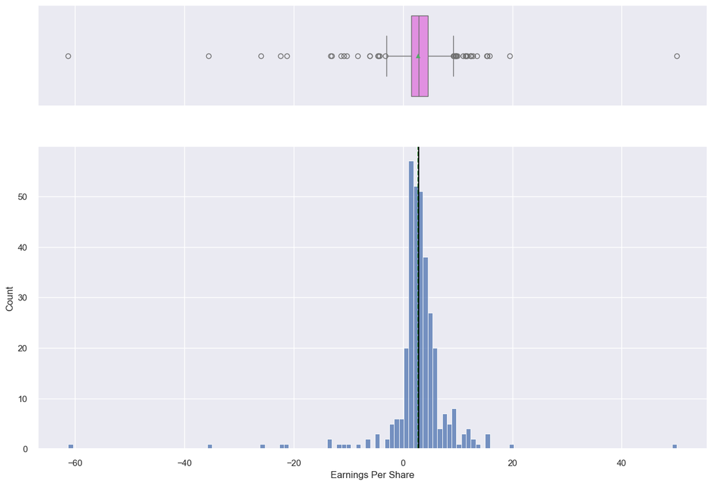

```python
# Calculate statistics and plot a histogram and boxplot.
calculate_statistics (data=df, feature="Earnings Per Share")
histogram_boxplot(df, 'Earnings Per Share')
```

#### Observations

- Mean: The average EPS is approximately $\$2.78$.
- Median: The median EPS is $\$2.895$, which is slightly higher than the mean.
- Range: The EPS values range from a minimum of $\$-61.2$ to a maximum of $\$50.09$, indicating a substantial spread in EPS values among the companies.
- Standard Deviation: The standard deviation is $\$6.59$, suggesting considerable dispersion around the mean. This high standard deviation relative to the mean indicates a wide variability in EPS values.
- There are both minimum and maximum outliers that appear to be normal in nature.

```
Discrete Statistics for Estimated Shares Outstanding

Mean              : 577028337.754030
Mode              : 199237804.9
Median            : 309675137.79999995
Min               : 27672156.86
Max               : 6159292035.0
Standard Deviation: 845849595.417695
Percentiles       :
0.25    1.588482e+08
0.50    3.096751e+08
0.75    5.731175e+08
Name: Estimated Shares Outstanding, dtype: float64
Minimum Whisker     : 27672156.860000
Maximum Whisker     : 1194521319.162500
```

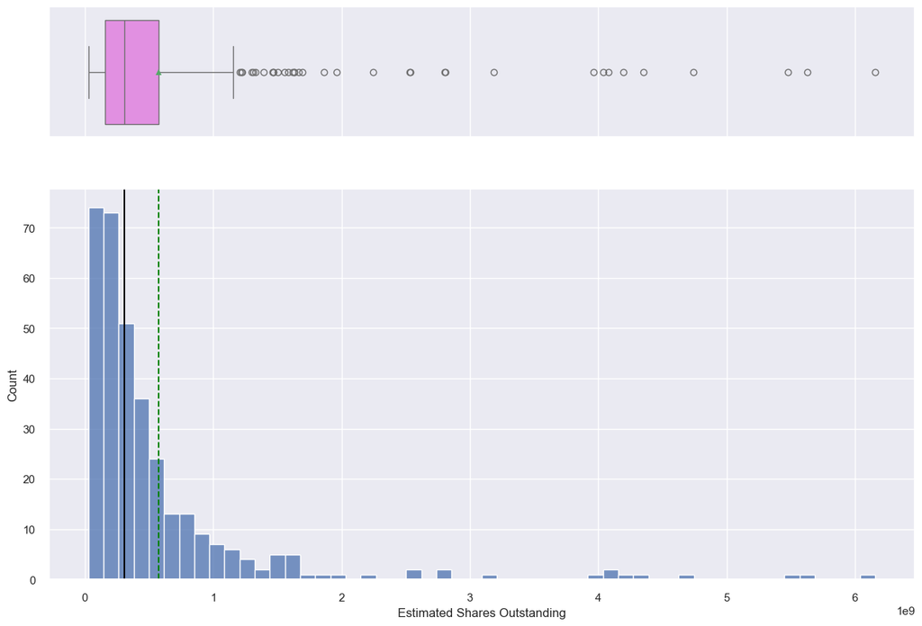

```python
# Calculate statistics and plot a histogram and boxplot.
calculate_statistics (data=df, feature='Estimated Shares Outstanding')
histogram_boxplot(df, 'Estimated Shares Outstanding')
```

#### Observations

- Mean: The average number of shares outstanding is approximately 577 million (577,028,337.75).
- Median: The median number of shares outstanding is approximately 310 million (309,675,137.80), which is significantly lower than the mean, suggesting a positive skew in the distribution.
- Range: The number of shares outstanding ranges from a minimum of approximately 27.7 million (27,672,156.86) to a maximum of approximately 6.16 billion (6,159,292,035.0), indicating a substantial spread in the number of shares outstanding among companies.
- Standard Deviation: The standard deviation is approximately 846 million (845,849,595.42), which is relatively large compared to the mean, indicating significant variability in the number of shares outstanding.
- There are maximum outliers that appear to be normal in nature.

```
Discrete Statistics for P/E Ratio

Mean              : 32.612563
Mode              : 93.0892875
Median            : 20.81987609
Min               : 2.935450768
Max               : 528.0390742
Standard Deviation: 44.348731
Percentiles       :
0.25    15.044653
0.50    20.819876
0.75    31.764755
Name: P/E Ratio, dtype: float64
Minimum Whisker     : 2.935451
Maximum Whisker     : 56.844909
```

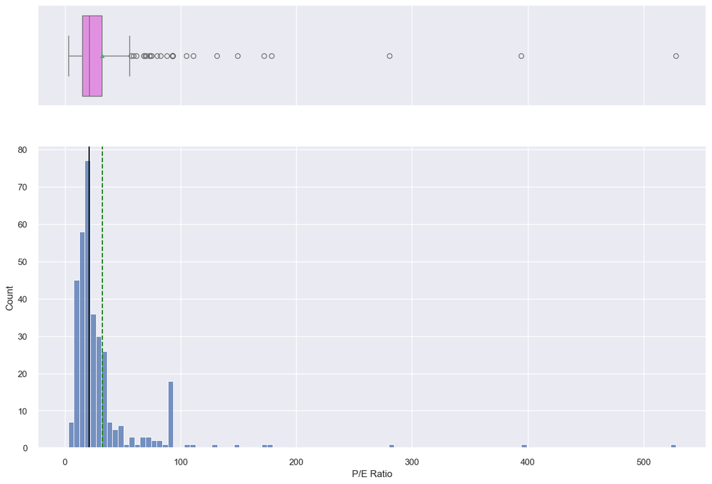

```python
# Calculate statistics and plot a histogram and boxplot.
calculate_statistics (data=df, feature="P/E Ratio")
histogram_boxplot(df, 'P/E Ratio')
```

#### Observations

- Mean: The average P/E ratio is approximately 32.61.
- Median: The median P/E ratio is approximately 20.82, which is lower than the mean, indicating a positive skew in the distribution.
- Range: The P/E ratio values range from a minimum of approximately 2.94 to a maximum of approximately 528.04, indicating a substantial spread in the P/E ratios among companies.
- Standard Deviation: The standard deviation is approximately 44.35, which is relatively high compared to the mean, indicating significant variability in the P/E ratios.
- There are maximum outliers that appear to be normal in nature.

```
Discrete Statistics for P/B Ratio

Mean              : -1.718249
Mode              : -1.269332159
Median            : -1.0671703205
Min               : -76.11907749
Max               : 129.0645854
Standard Deviation: 13.966912
Percentiles       :
0.25   -4.352056
0.50   -1.067170
0.75    3.917066
Name: P/B Ratio, dtype: float64
Minimum Whisker     : -16.755740
Maximum Whisker     : 16.320749
```

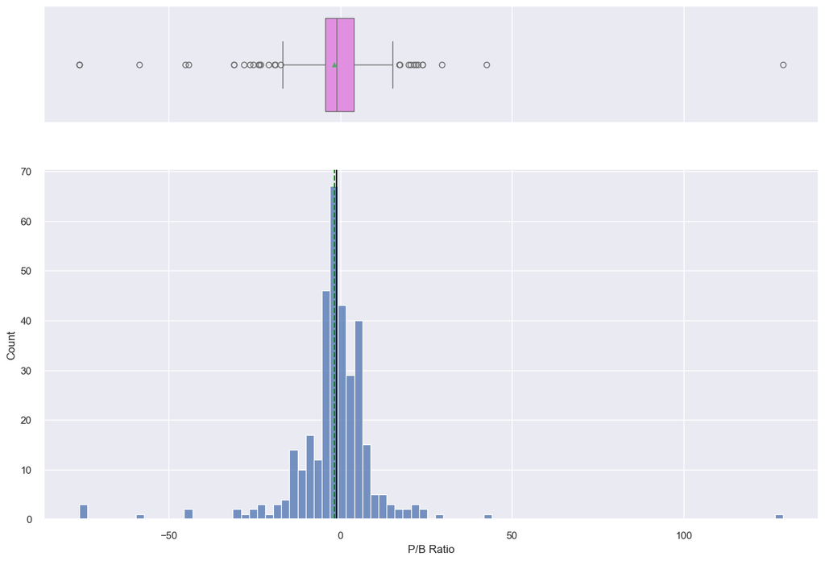

```python
# Calculate statistics and plot a histogram and boxplot.
calculate_statistics (data=df, feature="P/B Ratio")
histogram_boxplot(df, 'P/B Ratio')
```

#### Observations

- Mean: The average P/B ratio is approximately -1.72.
- Median: The median P/B ratio is approximately -1.07, which is closer to zero than the mean, indicating some balance but a tendency towards negative values.
- Range: The P/B ratio values range from a minimum of approximately -76.12 to a maximum of approximately 129.06, indicating a substantial spread and extreme values on both the negative and positive sides.
- Standard Deviation: The standard deviation is approximately 13.97, which is relatively large compared to the mean, indicating significant variability in the P/B ratios.
- Negative Mean and Median: The negative mean (-1.72) and median (-1.07) suggest that the majority of the companies in the dataset have negative P/B ratios.
  - P/B Ratio < 1:
    - The market values the company less than its book value. This could indicate the company is undervalued, has financial difficulties, or its assets are overvalued.

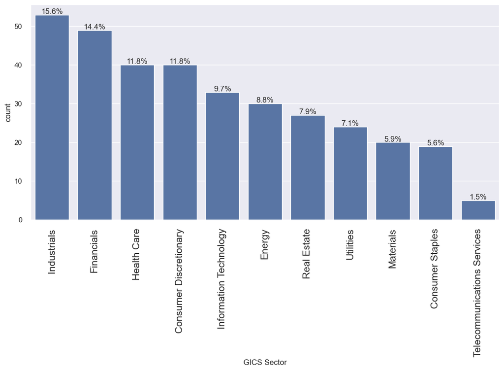

```python
labeled_barplot(df, 'GICS Sector', perc=True)
```

#### Observations

- The top three GICS Sectors (that make up 41.8%) are as follows:
  - Industrials
  - Financials
  - Health Care

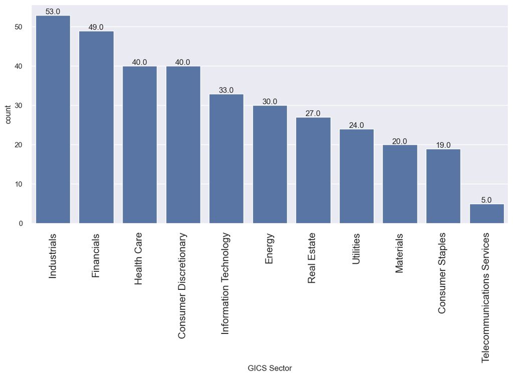

```python
labeled_barplot(df, 'GICS Sector', perc=False)
```

#### Observations

- The maximum number of Securities for a group (Industrials) is 53.
- The minimum number of Securities for a group (Telecommunicaitons Services) is 5.

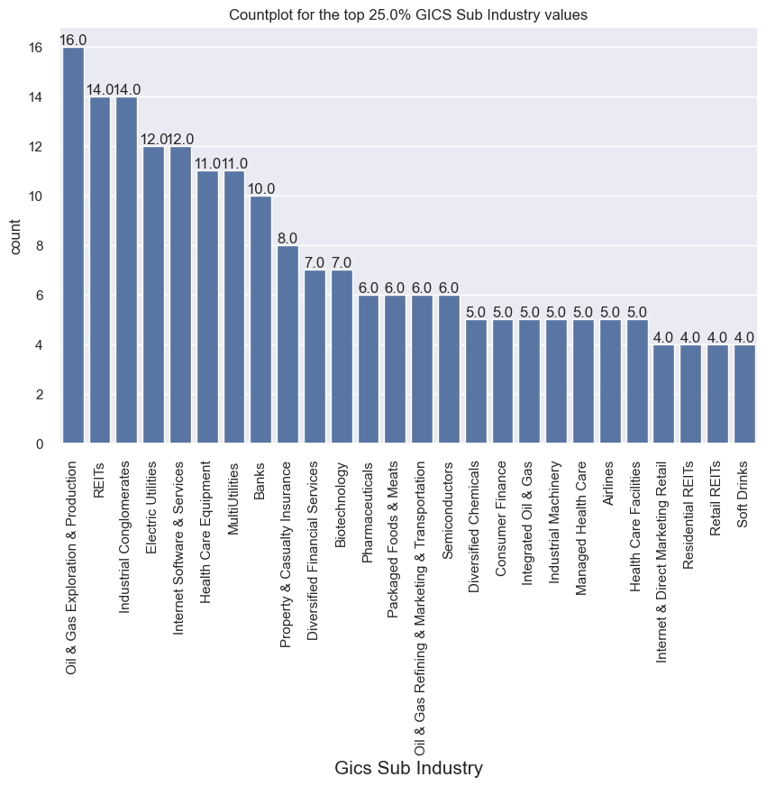

```python
countplot (input_data=df, feature='GICS Sub Industry', show_perc=.25, label_count=True)
```

#### Observations

- The top five (5) GICS Sub Industries are as follow:
  - Oil and Gas Exploration & Production
  - REITs
  - Industrial Conflomerates
  - Electric Utilities
  - Internet Software & Services

### Bivariate Analysis

**Questions**:

1. What does the distribution of stock prices look like?
2. The stocks of which economic sector have seen the maximum price increase on average?
3. How are the different variables correlated with each other?
4. Cash ratio provides a measure of a company's ability to cover its short-term obligations using only cash and cash equivalents. How does the average cash ratio vary across economic sectors?
5. P/E ratios can help determine the relative value of a company's shares as they signify the amount of money an investor is willing to invest in a single share of a company per dollar of its earnings. How does the P/E ratio vary, on average, across economic sectors?

### 1. What does the distribution of stock prices look like?

```
Discrete Statistics for Current Price

Mean              : 80.862345
Mode              : 32.93
Median            : 59.705
Min               : 4.5
Max               : 1274.949951
Standard Deviation: 98.055086
Percentiles       :
0.25    38.555000
0.50    59.705000
0.75    92.880001
Name: Current Price, dtype: float64
Minimum Whisker     : 4.500000
Maximum Whisker     : 174.367503
```

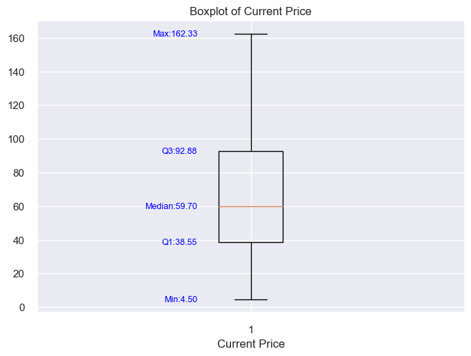

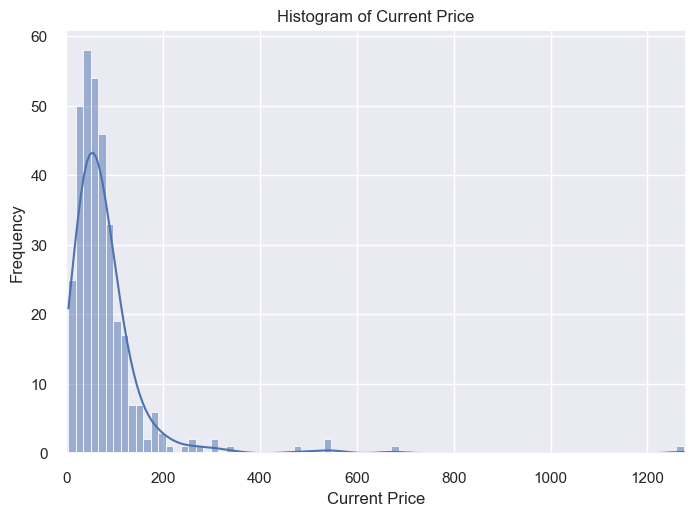

```python
calculate_statistics (data=df, feature="Current Price")
boxplot(input_data=df,feature="Current Price",in_vert=True,in_showfliers=False, in_showlabels=True)
histogram(input_data=df, feature="Current Price", in_kde=True)
```

#### Observations

- The `Current Price` has a right-skewed distribution.
- The `Current Price` has a mean of approximately $\$80.86$ and a median of approximately $\$59.70$.
- The minimum and maximum whisker values are approximately $\$4.5$ and $\$162.33$, respectively.

### 2. The stocks of which economic sector have seen the maximum price increase on average?

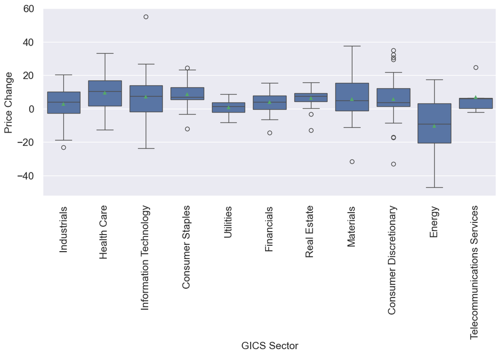

```python
multi_boxplot (in_data=df, x_feature='GICS Sector', y_feature='Price Change')
```

#### Observation:

- The stocks in the `Health Care` Industry sector, on average, has seen the highest price change.

### 3. How are the different variables correlated with each other?

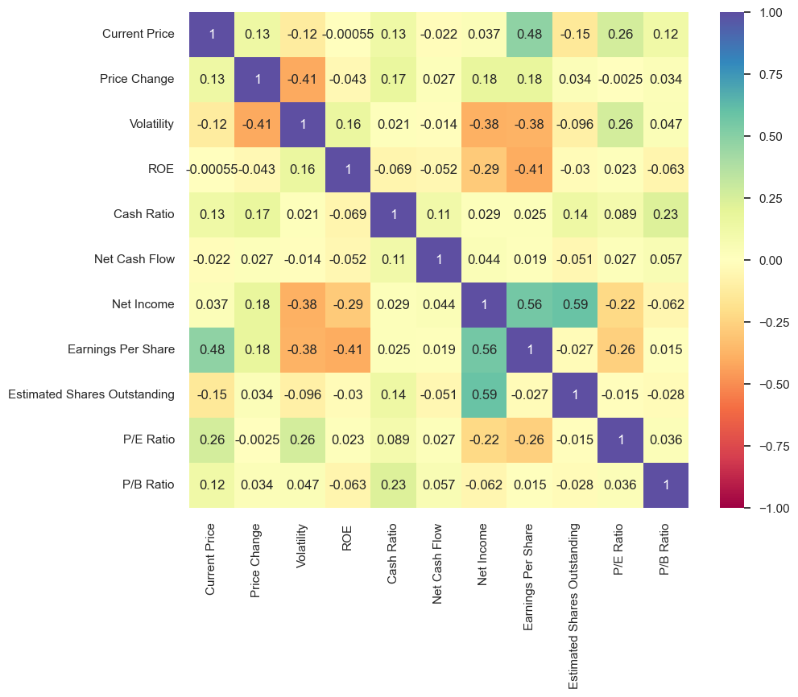

```python
heatmap (df)
```

#### Observations

$Net Income$ $=$ $EPS$ $\times$ $Estimated Shares Outstanding$

- `Earnings Per Share` and `Estimated Shares Outstanding` have a moderate positive correlation with `Net Income`; which is reasonable due to the `Net Income` formula.

$P/E$ $Ratio$ $=$ $\frac{Current Price}{Earnings Per Share}$

- Expected to see a higher correlation between `P/E Ratio` and `Current Price` and `Earnings Per Share`

### 4. Cash ratio provides a measure of a company's ability to cover its short-term obligations using only cash and cash equivalents. How does the average cash ratio vary across economic sectors?

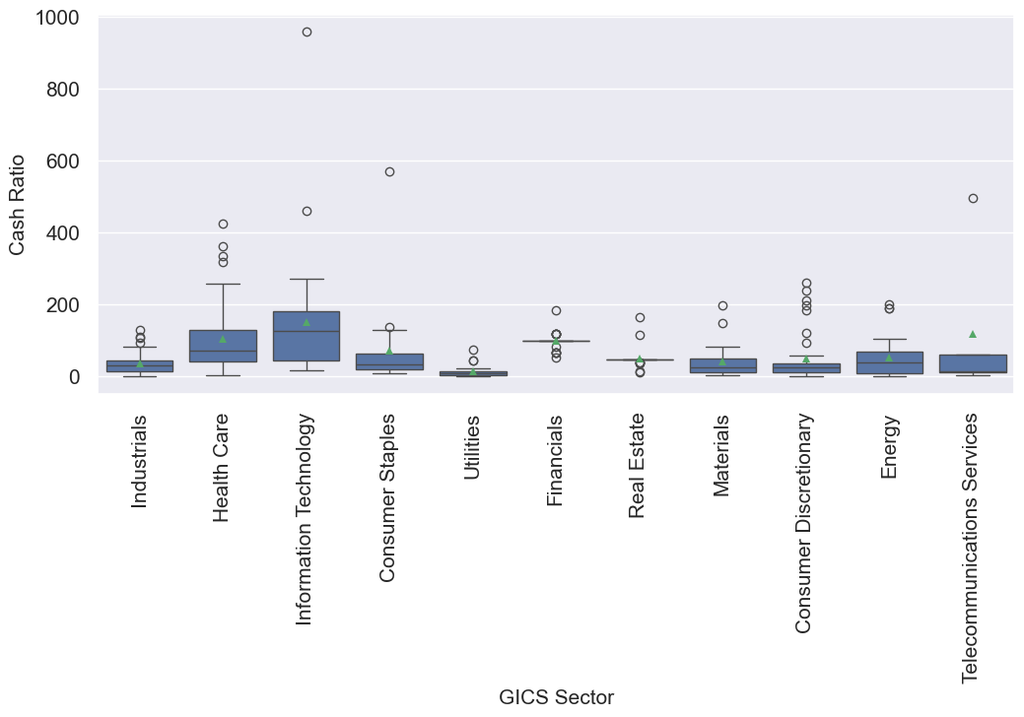

```python
multi_boxplot (in_data=df, x_feature='GICS Sector', y_feature='Cash Ratio')
```

### 5. P/E ratios can help determine the relative value of a company's shares as they signify the amount of money an investor is willing to invest in a single share of a company per dollar of its earnings. How does the P/E ratio vary, on average, across economic sectors?

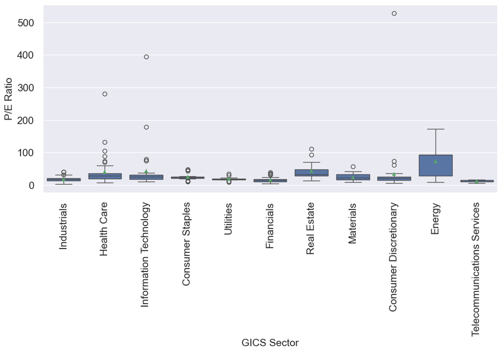

```python
multi_boxplot (in_data=df, x_feature='GICS Sector', y_feature='P/E Ratio')
```

#### Observations

- The **Energy** sector, on average, has the highest P/E Ratio; followed by the **Real Estate** sector.

## Data Preprocessing

- Duplicate value check
- Missing value treatment
- Outlier check
- Feature engineering (if needed)
- Any other preprocessing steps (if needed)

#### Make a copy of DataFrame

```python
df_copy = df.copy()
```

```python
# Quick check to ensure copy worked.
df_copy.info()
```

```
<class 'pandas.core.frame.DataFrame'>
RangeIndex: 340 entries, 0 to 339
Data columns (total 15 columns):
 #   Column                        Non-Null Count  Dtype
---  ------                        --------------  -----
 0   Ticker Symbol                 340 non-null    object
 1   Security                      340 non-null    object
 2   GICS Sector                   340 non-null    object
 3   GICS Sub Industry             340 non-null    object
 4   Current Price                 340 non-null    float64
 5   Price Change                  340 non-null    float64
 6   Volatility                    340 non-null    float64
 7   ROE                           340 non-null    int64
 8   Cash Ratio                    340 non-null    int64
 9   Net Cash Flow                 340 non-null    int64
 10  Net Income                    340 non-null    int64
 11  Earnings Per Share            340 non-null    float64
 12  Estimated Shares Outstanding  340 non-null    float64
 13  P/E Ratio                     340 non-null    float64
 14  P/B Ratio                     340 non-null    float64
dtypes: float64(7), int64(4), object(4)
memory usage: 40.0+ KB
```

#### Duplicate value check

- There are no duplicate values to remove

#### Missing value treatment

- There are no missing value treatments needed

#### Outlier check

- Outlier checks were perfomed in EDA above. No outlier treatment required.

#### Feature engineering (if needed)

- Notes:
  - The new features did not yield any better clustering.
  - This code was commented out to document an attempt to perform feature engineering for improved clustering.
- $Earnings Yield$ $=$ $\frac{1}{P/E Ratio}$
- Explanation: It helps investors assess the return on investment based on current earnings relative to the stock price.

```python
#df_copy['Earnings Yield'] = 1.0 / df_copy['P/E Ratio']
```

- `Cash Flow to Revenue Ratio` $=$ $\frac{Net Income}{Net Cash Flow}$
- Explanation: It indicates how effectively a company converts its revenue into actual cash flow, which is crucial for liquidity and financial health assessment.

```python
#df_copy['Cash Flow to Revenue Ratio'] = df_copy['Net Income']/df['Net Cash Flow']
```

```python
# Let's review a sample of rows to ensure the two new features were created properly
#df_copy.sample(n=5)
```

```python
# In an effort to improve original clustering, attempted to convert the GIC Sector into numerics to include in the
# KMeans clustering algorithm. However, it just created a cluster for each GIS Sector which did not provide any
# additional insights. Commented out to show attempt. However, in practice these statements would be removed.

# Initialize TF-IDF Vectorizer
#tfidf_vectorizer = TfidfVectorizer()

# Fit and transform the 'GICS Sector' field
#tfidf_matrix = tfidf_vectorizer.fit_transform(df_copy['GICS Sector'])

# Convert the TF-IDF matrix to a DataFrame
#tfidf_df = pd.DataFrame(tfidf_matrix.toarray(), columns=tfidf_vectorizer.get_feature_names_out())
```

```python
#tfidf_df.describe().T
```

```python
# Combine TF-IDF encoded columns with the original DataFrame
#df_combined = pd.concat([df_copy, tfidf_df], axis=1).drop(columns=['GICS Sector'])
```

```python
#df_combined.info()
```

```python
#df_combined.head(20)
```

### Summary of Iterations

- In the first pass of KMeans clustering, there were few clusters with one very large cluster.
- Seemed like there had to be a way to get a better set of clusters that were a little more evenly sized.
- Attempt 1: Create some new ratios using existing features.
  - This did not result in any better results.
- Attempt 2: Use the TF-IDF Vectorizer to convert the GICS Sector into numeric fields weighted by occurence in data-set.
  - This did produce 11 better sized clusters, but they were each associated with a GICS Sector.
  - This seemed to contradict the purpose of this assignment by having a cluster=GICS Sector value.
- Perhaps, the Heirarchial Clustering technique will prove to be better.

#### Let's standardize our features by scaling them (using zscores)

```python
# Scaling the data set before clustering. Scaling with convert each feature to zscores to allow them
# to be compared easier.

# Grab all the numeric based fields
numeric_columns = df_copy.columns[df_copy.dtypes.apply(pd.api.types.is_numeric_dtype)]
numeric_columns
```

```
Index(['Current Price', 'Price Change', 'Volatility', 'ROE', 'Cash Ratio',
       'Net Cash Flow', 'Net Income', 'Earnings Per Share',
       'Estimated Shares Outstanding', 'P/E Ratio', 'P/B Ratio'],
      dtype='object')
```

```python
# Prep the scaler and the numpy array of just numeric columns
scaler = StandardScaler()
subset = df_copy[numeric_columns].copy()

# Standardize the values
subset_scaled_df = scaler.fit_transform(subset)
```

```python
# creating a dataframe of the scaled data
subset_scaled_df = pd.DataFrame(subset_scaled_df, columns=subset.columns)
```

```python
# Recheck the new DataFrame to ensure correctness.
subset_scaled_df.info()
```

```
<class 'pandas.core.frame.DataFrame'>
RangeIndex: 340 entries, 0 to 339
Data columns (total 11 columns):
 #   Column                        Non-Null Count  Dtype
---  ------                        --------------  -----
 0   Current Price                 340 non-null    float64
 1   Price Change                  340 non-null    float64
 2   Volatility                    340 non-null    float64
 3   ROE                           340 non-null    float64
 4   Cash Ratio                    340 non-null    float64
 5   Net Cash Flow                 340 non-null    float64
 6   Net Income                    340 non-null    float64
 7   Earnings Per Share            340 non-null    float64
 8   Estimated Shares Outstanding  340 non-null    float64
 9   P/E Ratio                     340 non-null    float64
 10  P/B Ratio                     340 non-null    float64
dtypes: float64(11)
memory usage: 29.3 KB
```

```python
subset_scaled_df.head(5)
```

|  | Current Price | Price Change | Volatility | ROE | Cash Ratio | Net Cash Flow | Net Income | Earnings Per Share | Estimated Shares Outstanding | P/E Ratio | P/B Ratio |
| --- | --- | --- | --- | --- | --- | --- | --- | --- | --- | --- | --- |
| 0 | -0.393341 | 0.493950 | 0.272749 | 0.989601 | -0.210698 | -0.339355 | 1.554415 | 1.309399 | 0.107863 | -0.652487 | -0.506653 |
| 1 | -0.220837 | 0.355439 | 1.137045 | 0.937737 | 0.077269 | -0.002335 | 0.927628 | 0.056755 | 1.250274 | -0.311769 | -0.504205 |
| 2 | -0.367195 | 0.602479 | -0.427007 | -0.192905 | -0.033488 | 0.454058 | 0.744371 | 0.024831 | 1.098021 | -0.391502 | 0.094941 |
| 3 | 0.133567 | 0.825696 | -0.284802 | -0.317379 | 1.218059 | -0.152497 | -0.219816 | -0.230563 | -0.091622 | 0.947148 | 0.424333 |
| 4 | -0.260874 | -0.492636 | 0.296470 | -0.265515 | 2.237018 | 0.133564 | -0.202703 | -0.374982 | 1.978399 | 3.293307 | 0.199196 |

## EDA

- It is a good idea to explore the data once again after manipulating it.

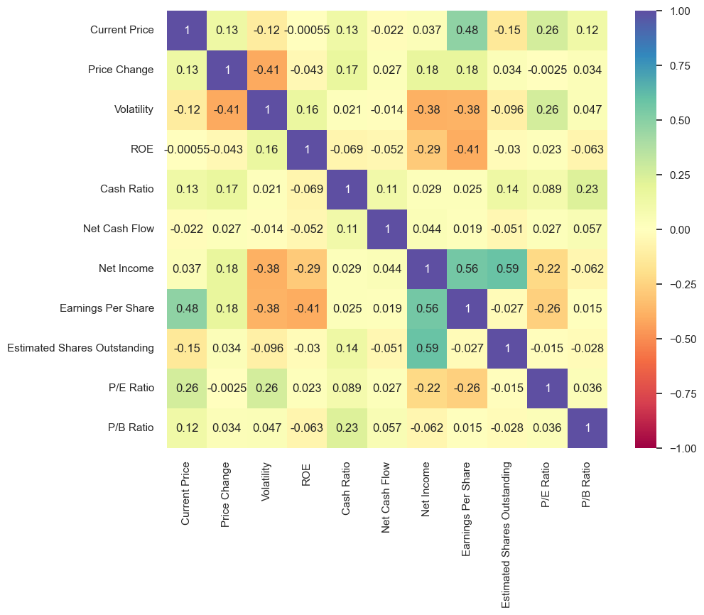

```python
heatmap (subset_scaled_df)
```

## K-means Clustering

```
Number of Clusters: 1 	Average Distortion: 2.5425069919221697
Number of Clusters: 2 	Average Distortion: 2.377354137922532
Number of Clusters: 3 	Average Distortion: 2.2832763769865085
Number of Clusters: 4 	Average Distortion: 2.304104178991299
Number of Clusters: 5 	Average Distortion: 2.1108750333559665
Number of Clusters: 6 	Average Distortion: 2.099428651856189
Number of Clusters: 7 	Average Distortion: 2.017575761474135
Number of Clusters: 8 	Average Distortion: 1.9539912343828287
Number of Clusters: 9 	Average Distortion: 1.947403360893657
Number of Clusters: 10 	Average Distortion: 1.9101192453581084
Number of Clusters: 11 	Average Distortion: 1.8131244818046528
Number of Clusters: 12 	Average Distortion: 1.7981158517907585
Number of Clusters: 13 	Average Distortion: 1.7578938212100739
Number of Clusters: 14 	Average Distortion: 1.7415376018243458
```

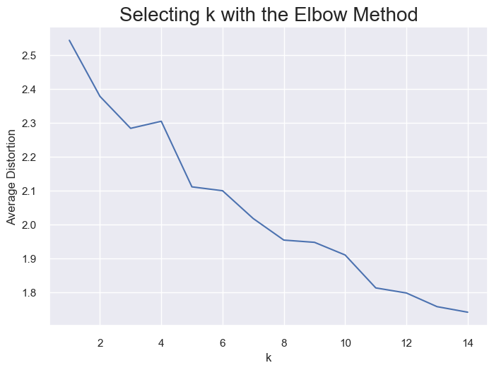

```python
clusters = range(1, 15)
meanDistortions = []

for k in clusters:
    model = KMeans(n_clusters=k,n_init='auto')
    model.fit(subset_scaled_df)
    prediction = model.predict(subset_scaled_df)
    distortion = (
        sum(
            np.min(cdist(subset_scaled_df, model.cluster_centers_, "euclidean"), axis=1)
        )
        / subset_scaled_df.shape[0]
    )

    meanDistortions.append(distortion)

    print("Number of Clusters:", k, "\tAverage Distortion:", distortion)

plt.plot(clusters, meanDistortions, "bx-")
plt.xlabel("k")
plt.ylabel("Average Distortion")
plt.title("Selecting k with the Elbow Method", fontsize=20)
```

#### Observations

- Based on the elbow method there is a slight tick at k=5 for the number of clusters.

### Let's check the silhouette scores

```
For n_clusters = 2, silhouette score is 0.5955010624601881
For n_clusters = 3, silhouette score is 0.44403603548910386
For n_clusters = 4, silhouette score is 0.45017906939331087
For n_clusters = 5, silhouette score is 0.41753613938362666
For n_clusters = 6, silhouette score is 0.4012972336589006
For n_clusters = 7, silhouette score is 0.40829513504452447
For n_clusters = 8, silhouette score is 0.12091064898063597
For n_clusters = 9, silhouette score is 0.10718895673973365
For n_clusters = 10, silhouette score is 0.29286294928196677
For n_clusters = 11, silhouette score is 0.11451395323090324
For n_clusters = 12, silhouette score is 0.16606809652316504
For n_clusters = 13, silhouette score is 0.23065204399134248
For n_clusters = 14, silhouette score is 0.15366928217820822
```

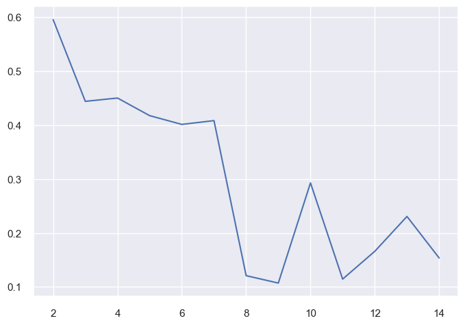

```python
sil_score = []
cluster_list = list(range(2, 15))
for n_clusters in cluster_list:
    clusterer = KMeans(n_clusters=n_clusters,n_init='auto')
    preds = clusterer.fit_predict((subset_scaled_df))
    # centers = clusterer.cluster_centers_
    score = silhouette_score(subset_scaled_df, preds)
    sil_score.append(score)
    print("For n_clusters = {}, silhouette score is {}".format(n_clusters, score))

plt.plot(cluster_list, sil_score)
```

#### Observation

- Using silhouette scores, n_clusters=5, has a decent score.
- Additionally, n_clusters=6 has a decent score compared to the others and offers a potential of more clusters.
- Ruling out n_clusters=7 since it has a large drop-off at n_clusters=8. It's possible, n_clusters=7 is rated higher than it should be.

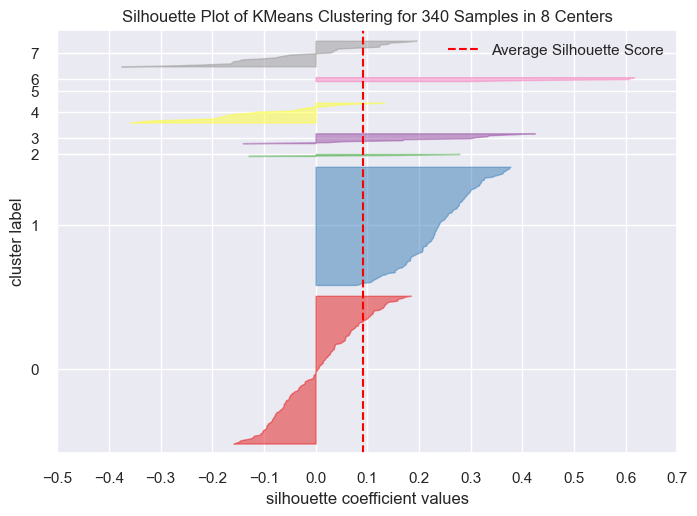

```python
# finding optimal no. of clusters with silhouette coefficients
visualizer = SilhouetteVisualizer(KMeans(8, random_state=1,n_init='auto'))
visualizer.fit(subset_scaled_df)
visualizer.show()
```

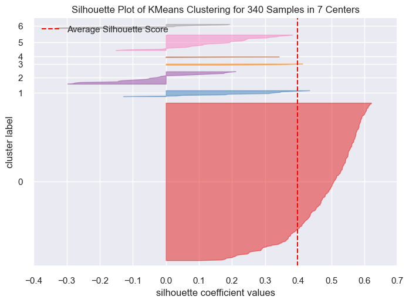

```python
# finding optimal no. of clusters with silhouette coefficients
visualizer = SilhouetteVisualizer(KMeans(7, random_state=1,n_init='auto'))
visualizer.fit(subset_scaled_df)
visualizer.show()
```

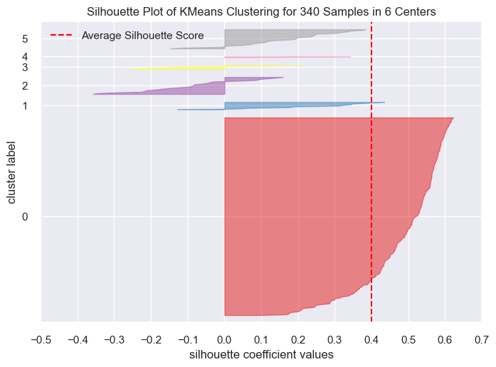

```python
# finding optimal no. of clusters with silhouette coefficients
visualizer = SilhouetteVisualizer(KMeans(6, random_state=1,n_init='auto'))
visualizer.fit(subset_scaled_df)
visualizer.show()
```

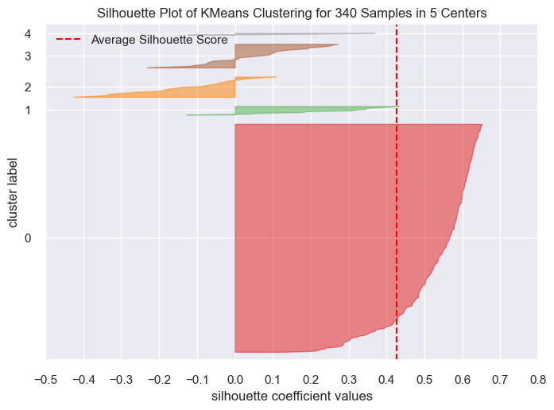

```python
# finding optimal no. of clusters with silhouette coefficients
visualizer = SilhouetteVisualizer(KMeans(5, random_state=1,n_init='auto'))
visualizer.fit(subset_scaled_df)
visualizer.show()
```

### Select the model

```python
subset_scaled_df.head()
```

|  | Current Price | Price Change | Volatility | ROE | Cash Ratio | Net Cash Flow | Net Income | Earnings Per Share | Estimated Shares Outstanding | P/E Ratio | P/B Ratio |
| --- | --- | --- | --- | --- | --- | --- | --- | --- | --- | --- | --- |
| 0 | -0.393341 | 0.493950 | 0.272749 | 0.989601 | -0.210698 | -0.339355 | 1.554415 | 1.309399 | 0.107863 | -0.652487 | -0.506653 |
| 1 | -0.220837 | 0.355439 | 1.137045 | 0.937737 | 0.077269 | -0.002335 | 0.927628 | 0.056755 | 1.250274 | -0.311769 | -0.504205 |
| 2 | -0.367195 | 0.602479 | -0.427007 | -0.192905 | -0.033488 | 0.454058 | 0.744371 | 0.024831 | 1.098021 | -0.391502 | 0.094941 |
| 3 | 0.133567 | 0.825696 | -0.284802 | -0.317379 | 1.218059 | -0.152497 | -0.219816 | -0.230563 | -0.091622 | 0.947148 | 0.424333 |
| 4 | -0.260874 | -0.492636 | 0.296470 | -0.265515 | 2.237018 | 0.133564 | -0.202703 | -0.374982 | 1.978399 | 3.293307 | 0.199196 |

```python
# creating a copy of the original data
df1 = df.copy()
k_means_df = subset_scaled_df.copy()

kmeans = KMeans(n_clusters=6, random_state=0,n_init='auto')
kmeans.fit(subset_scaled_df)
```

```
KMeans(n_clusters=6, n_init='auto', random_state=0)
```

```python
# adding kmeans cluster labels to the original and scaled dataframes
k_means_df["KMeans_segments"] = kmeans.labels_
df1["KMeans_segments"] = kmeans.labels_
```

```python
df1.sample(10)
```

|  | Ticker Symbol | Security | GICS Sector | GICS Sub Industry | Current Price | Price Change | Volatility | ROE | Cash Ratio | Net Cash Flow | Net Income | Earnings Per Share | Estimated Shares Outstanding | P/E Ratio | P/B Ratio | KMeans_segments |
| --- | --- | --- | --- | --- | --- | --- | --- | --- | --- | --- | --- | --- | --- | --- | --- | --- |
| 116 | ETN | Eaton Corporation | Industrials | Industrial Conglomerates | 52.040001 | 1.166411 | 1.521430 | 13 | 10 | -513000000 | 1979000000 | 4.25 | 4.656471e+08 | 12.244706 | -8.639591 | 5 |
| 151 | HCN | Welltower Inc. | Real Estate | REITs | 68.029999 | 0.044116 | 1.341731 | 6 | 47 | -112818000 | 849073000 | 2.35 | 3.613077e+08 | 28.948936 | -3.738047 | 5 |
| 324 | WU | Western Union Co | Information Technology | Internet Software & Services | 17.910000 | -2.610109 | 1.273051 | 60 | 16 | -467300000 | 837800000 | 1.63 | 5.139877e+08 | 10.987730 | -8.043772 | 5 |
| 277 | SPG | Simon Property Group Inc | Real Estate | REITs | 194.440002 | 5.284822 | 1.135546 | 48 | 47 | 88852000 | 2139375000 | 5.88 | 3.638393e+08 | 33.068028 | -1.269332 | 5 |
| 327 | WYNN | Wynn Resorts Ltd | Consumer Discretionary | Casinos & Gaming | 69.190002 | 29.496541 | 3.794783 | 174 | 198 | -102075000 | 195290000 | 1.93 | 1.011865e+08 | 35.849742 | 12.695712 | 1 |
| 148 | HAS | Hasbro Inc. | Consumer Discretionary | Leisure Products | 67.360001 | -7.076834 | 1.583355 | 27 | 92 | 83583000 | 451838000 | 3.61 | 1.251629e+08 | 18.659280 | 12.145326 | 5 |
| 337 | ZBH | Zimmer Biomet Holdings | Health Care | Health Care Equipment | 102.589996 | 9.347683 | 1.404206 | 1 | 100 | 376000000 | 147000000 | 0.78 | 1.884615e+08 | 131.525636 | -23.884449 | 5 |
| 210 | MMM | 3M Company | Industrials | Industrial Conglomerates | 150.639999 | 5.927847 | 0.982698 | 42 | 27 | -99000000 | 4833000000 | 7.72 | 6.260363e+08 | 19.512953 | 2.023844 | 5 |
| 46 | BK | The Bank of New York Mellon Corp. | Financials | Banks | 41.220001 | 5.422003 | 1.201660 | 8 | 99 | -433000000 | 3158000000 | 2.73 | 1.156777e+09 | 15.098901 | -3.321298 | 5 |
| 163 | HUM | Humana Inc. | Health Care | Managed Health Care | 178.509995 | -0.145443 | 1.615206 | 12 | 70 | 636000000 | 1276000000 | 8.54 | 1.494145e+08 | 20.902810 | -8.805281 | 5 |

### Clustering Profile

```python
cluster_profile = df1.groupby("KMeans_segments").mean(numeric_only=True)
```

```python
cluster_profile["count_in_each_segment"] = (
    df1.groupby("KMeans_segments")["Security"].count().values
)
```

```python
cluster_profile.style.highlight_max(color="lightgreen", axis=0)
```

| KMeans_segments | Current Price | Price Change | Volatility | ROE | Cash Ratio | Net Cash Flow | Net Income | Earnings Per Share | Estimated Shares Outstanding | P/E Ratio | P/B Ratio | count_in_each_segment |
| --- | --- | --- | --- | --- | --- | --- | --- | --- | --- | --- | --- | --- |
| 0 | 52.142857 | 6.779993 | 1.175153 | 26.142857 | 140.142857 | 760285714.285714 | 13368785714.285715 | 3.769286 | 3838879870.871428 | 20.654832 | -3.529270 | 14 |
| 1 | 43.152401 | -10.892145 | 2.483219 | 21.783784 | 99.297297 | 24839216.216216 | -871247675.675676 | -1.929730 | 493001931.442703 | 62.071158 | 3.053327 | 37 |
| 2 | 21.235000 | -20.327010 | 3.447817 | 401.333333 | 30.000000 | -340333333.333333 | -12123500000.000000 | -26.290000 | 513567940.283333 | 70.596172 | 1.497710 | 6 |
| 3 | 108.304002 | 10.737770 | 1.165694 | 566.200000 | 26.600000 | -278760000.000000 | 687180000.000000 | 1.548000 | 349607057.720000 | 34.898915 | -16.851358 | 5 |
| 4 | 489.313326 | 9.749852 | 1.687223 | 14.555556 | 152.666667 | 248373888.888889 | 655419333.333333 | 11.315556 | 160803192.135556 | 167.363342 | 24.013287 | 9 |
| 5 | 74.698173 | 6.227509 | 1.371005 | 25.728625 | 61.282528 | 31673513.011152 | 1548588308.550186 | 3.757825 | 438392466.621822 | 23.784868 | -2.931662 | 269 |

```
['Current Price', 'Price Change', 'Volatility', 'ROE', 'Cash Ratio', 'Net Cash Flow', 'Net Income', 'Earnings Per Share', 'Estimated Shares Outstanding', 'P/E Ratio', 'P/B Ratio']
```

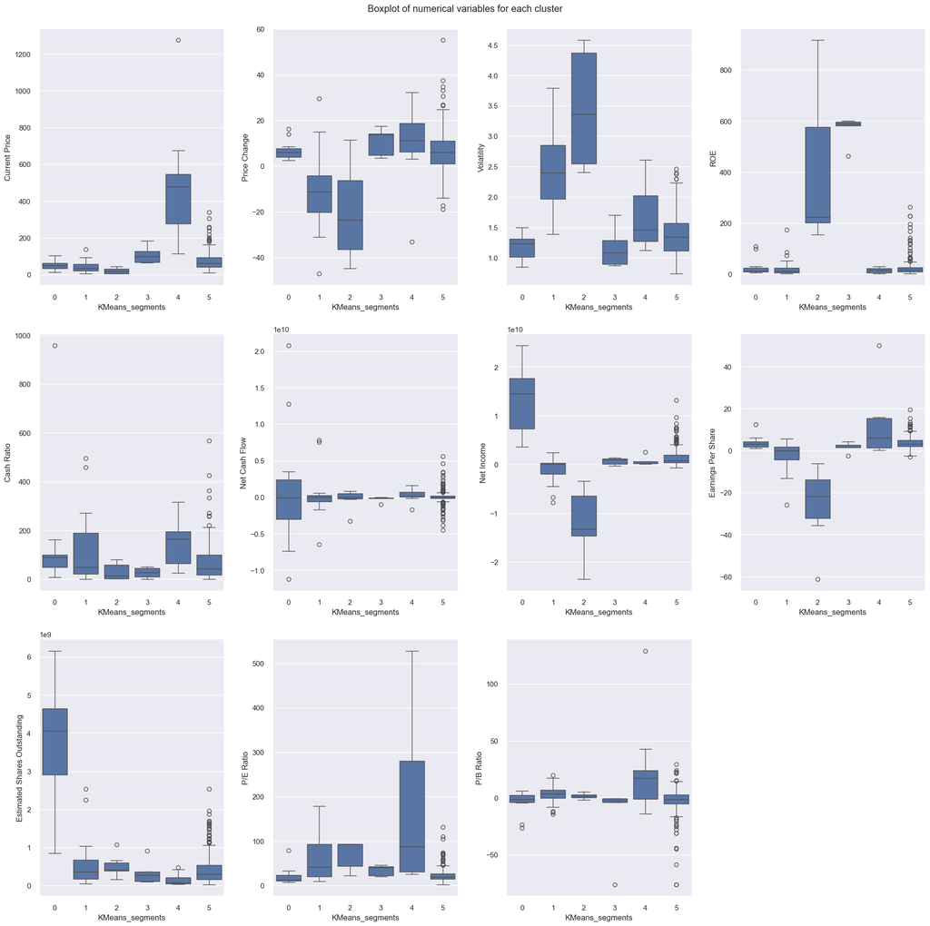

```python
plt.figure(figsize=(20, 20))
plt.suptitle("Boxplot of numerical variables for each cluster")

# selecting numerical columns
num_col = df.select_dtypes(include=np.number).columns.tolist()
print(num_col)

for i, variable in enumerate(num_col):
    plt.subplot(3, 4, i + 1)
    sns.boxplot(data=df1, x="KMeans_segments", y=variable)

plt.tight_layout(pad=2.0)
```

## Hierarchical Clustering

### Computing Cophenetic Correlation

```python
# Let's make a backup of the scaled DataFrame
hc_df = subset_scaled_df.copy()
```

```python
# list of distance metrics
distance_metrics = ["euclidean", "chebyshev", "mahalanobis", "cityblock"]

# list of linkage methods
linkage_methods = ["single", "complete", "average", "weighted"]

high_cophenet_corr = 0
high_dm_lm = [0, 0]

for dm in distance_metrics:
    for lm in linkage_methods:
        Z = linkage(hc_df, metric=dm, method=lm)
        c, coph_dists = cophenet(Z, pdist(hc_df))
        print(
            "Cophenetic correlation for {} distance and {} linkage is {}.".format(
                dm.capitalize(), lm, c
            )
        )
        if high_cophenet_corr < c:
            high_cophenet_corr = c
            high_dm_lm[0] = dm
            high_dm_lm[1] = lm
```

```
Cophenetic correlation for Euclidean distance and single linkage is 0.9232271494002922.
Cophenetic correlation for Euclidean distance and complete linkage is 0.7873280186580672.
Cophenetic correlation for Euclidean distance and average linkage is 0.9422540609560814.
Cophenetic correlation for Euclidean distance and weighted linkage is 0.8693784298129404.
Cophenetic correlation for Chebyshev distance and single linkage is 0.9062538164750717.
Cophenetic correlation for Chebyshev distance and complete linkage is 0.598891419111242.
Cophenetic correlation for Chebyshev distance and average linkage is 0.9338265528030499.
Cophenetic correlation for Chebyshev distance and weighted linkage is 0.9127355892367.
Cophenetic correlation for Mahalanobis distance and single linkage is 0.9259195530524591.
Cophenetic correlation for Mahalanobis distance and complete linkage is 0.7925307202850002.
Cophenetic correlation for Mahalanobis distance and average linkage is 0.9247324030159736.
Cophenetic correlation for Mahalanobis distance and weighted linkage is 0.8708317490180427.
Cophenetic correlation for Cityblock distance and single linkage is 0.9334186366528574.
Cophenetic correlation for Cityblock distance and complete linkage is 0.7375328863205818.
Cophenetic correlation for Cityblock distance and average linkage is 0.9302145048594667.
Cophenetic correlation for Cityblock distance and weighted linkage is 0.731045513520281.
```

```python
# printing the combination of distance metric and linkage method with the highest cophenetic correlation
print(
    "Highest cophenetic correlation is {}, which is obtained with {} distance and {} linkage.".format(
        high_cophenet_corr, high_dm_lm[0].capitalize(), high_dm_lm[1]
    )
)
```

```
Highest cophenetic correlation is 0.9422540609560814, which is obtained with Euclidean distance and average linkage.
```

**Let's explore different linkage methods with Euclidean distance only.**

```python
# list of linkage methods
linkage_methods = ["single", "complete", "average", "centroid", "ward", "weighted"]

high_cophenet_corr = 0
high_dm_lm = [0, 0]

for lm in linkage_methods:
    Z = linkage(hc_df, metric="euclidean", method=lm)
    c, coph_dists = cophenet(Z, pdist(hc_df))
    print("Cophenetic correlation for {} linkage is {}.".format(lm, c))
    if high_cophenet_corr < c:
        high_cophenet_corr = c
        high_dm_lm[0] = "euclidean"
        high_dm_lm[1] = lm
```

```
Cophenetic correlation for single linkage is 0.9232271494002922.
Cophenetic correlation for complete linkage is 0.7873280186580672.
Cophenetic correlation for average linkage is 0.9422540609560814.
Cophenetic correlation for centroid linkage is 0.9314012446828154.
Cophenetic correlation for ward linkage is 0.7101180299865353.
Cophenetic correlation for weighted linkage is 0.8693784298129404.
```

```python
# printing the combination of distance metric and linkage method with the highest cophenetic correlation
print(
    "Highest cophenetic correlation is {}, which is obtained with {} linkage.".format(
        high_cophenet_corr, high_dm_lm[1]
    )
)
```

```
Highest cophenetic correlation is 0.9422540609560814, which is obtained with average linkage.
```

**We see that the cophenetic correlation is maximum with Euclidean distance and average linkage.**

### Checking Dendrograms

**Let's see the dendrograms for the different linkage methods.**

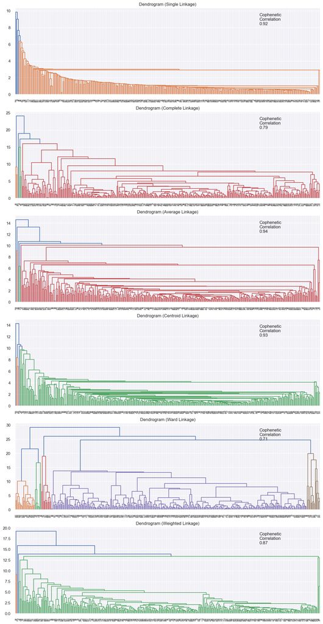

```python
# list of linkage methods
linkage_methods = ["single", "complete", "average", "centroid", "ward", "weighted"]

# lists to save results of cophenetic correlation calculation
compare_cols = ["Linkage", "Cophenetic Coefficient"]

# to create a subplot image
fig, axs = plt.subplots(len(linkage_methods), 1, figsize=(15, 30))

# We will enumerate through the list of linkage methods above
# For each linkage method, we will plot the dendrogram and calculate the cophenetic correlation
for i, method in enumerate(linkage_methods):
    Z = linkage(hc_df, metric="euclidean", method=method)

    dendrogram(Z, ax=axs[i])
    axs[i].set_title(f"Dendrogram ({method.capitalize()} Linkage)")

    coph_corr, coph_dist = cophenet(Z, pdist(hc_df))
    axs[i].annotate(
        f"Cophenetic\nCorrelation\n{coph_corr:0.2f}",
        (0.80, 0.80),
        xycoords="axes fraction",
    )
```

**Observations**

- The cophenetic correlation is highest for average and centroid linkage methods.
- However, these do not appear to have balanced clusters.
- The Ward linkage has a lower Cophenetic score of .71, but it has a more balanced cluster when k=5.
- We will move ahead with ward linkage.
- Five (5) appears to be the appropriate number of clusters from the dendrogram for ward linkage.

### Creating Model using sklearn

```python
HCmodel = AgglomerativeClustering(n_clusters=5, affinity="euclidean", linkage="ward")
HCmodel.fit(hc_df)
```

```
AgglomerativeClustering(affinity='euclidean', n_clusters=5)
```

```python
# Assuming hc_df is your DataFrame with the data to be clustered
# Convert the DataFrame to a NumPy array if necessary
#X = hc_df.to_numpy()

# Perform hierarchical clustering using centroid linkage
#Z = linkage(X, method='centroid')

# Extract clusters (example with 4 clusters)
#clusters = fcluster(Z, t=5, criterion='maxclust')
```

```python
# creating a copy of the original data
#df2 = df.copy()

# Optionally, add the clusters to your DataFrame
#hc_df['HC_segments'] = clusters
#df2["HC_segments"] = clusters
```

```python
# creating a copy of the original data
df2 = df.copy()

# adding hierarchical cluster labels to the original and scaled dataframes
hc_df["HC_segments"] = HCmodel.labels_
df2["HC_segments"] = HCmodel.labels_
```

### Cluster Profiling

```python
cluster_profile = df2.groupby("HC_segments").mean()
```

```python
cluster_profile["count_in_each_segments"] = (
    df2.groupby("HC_segments")["Security"].count().values
)
```

```python
# let's see the names of the countries in each cluster
for cl in df2["HC_segments"].unique():
    print("In cluster {}, the following companies are present:".format(cl))
    print(df2[df2["HC_segments"] == cl]["Security"].unique())
    print()
```

```
In cluster 3, the following companies are present:
['American Airlines Group' 'AbbVie' 'Abbott Laboratories'
 'Adobe Systems Inc' 'Analog Devices, Inc.' 'Archer-Daniels-Midland Co'
 'Ameren Corp' 'American Electric Power' 'AFLAC Inc'
 'American International Group, Inc.' 'Apartment Investment & Mgmt'
 'Assurant Inc' 'Arthur J. Gallagher & Co.' 'Akamai Technologies Inc'
 'Albemarle Corp' 'Alaska Air Group Inc' 'Allstate Corp'
 'Applied Materials Inc' 'AMETEK Inc' 'Affiliated Managers Group Inc'
 'Ameriprise Financial' 'American Tower Corp A' 'AutoNation Inc'
 'Anthem Inc.' 'Aon plc' 'Amphenol Corp' 'Arconic Inc'
 'Activision Blizzard' 'AvalonBay Communities, Inc.' 'Broadcom'
 'American Water Works Company Inc' 'American Express Co' 'Boeing Company'
 'Baxter International Inc.' 'BB&T Corporation' 'Bard (C.R.) Inc.'
 'BIOGEN IDEC Inc.' 'The Bank of New York Mellon Corp.' 'Ball Corp'
 'Bristol-Myers Squibb' 'Boston Scientific' 'BorgWarner'
 'Boston Properties' 'Caterpillar Inc.' 'Chubb Limited' 'CBRE Group'
 'Crown Castle International Corp.' 'Carnival Corp.' 'Celgene Corp.'
 'CF Industries Holdings Inc' 'Citizens Financial Group' 'Church & Dwight'
 'C. H. Robinson Worldwide' 'CIGNA Corp.' 'Cincinnati Financial'
 'Comerica Inc.' 'CME Group Inc.' 'Cummins Inc.' 'CMS Energy'
 'Centene Corporation' 'CenterPoint Energy' 'Capital One Financial'
 'The Cooper Companies' 'CSX Corp.' 'CenturyLink Inc'
 'Cognizant Technology Solutions' 'Citrix Systems' 'CVS Health'
 'Chevron Corp.' 'Dominion Resources' 'Delta Air Lines' 'Du Pont (E.I.)'
 'Deere & Co.' 'Discover Financial Services' 'Quest Diagnostics'
 'Danaher Corp.' 'The Walt Disney Company' 'Discovery Communications-A'
 'Discovery Communications-C' 'Delphi Automotive' 'Digital Realty Trust'
 'Dun & Bradstreet' 'Dover Corp.' 'Dr Pepper Snapple Group' 'Duke Energy'
 'DaVita Inc.' 'eBay Inc.' 'Ecolab Inc.' 'Consolidated Edison'
 'Equifax Inc.' "Edison Int'l" 'Eastman Chemical' 'Equity Residential'
 'EQT Corporation' 'Eversource Energy' 'Essex Property Trust, Inc.'
 'E*Trade' 'Eaton Corporation' 'Entergy Corp.' 'Edwards Lifesciences'
 'Exelon Corp.' "Expeditors Int'l" 'Expedia Inc.' 'Extra Space Storage'
 'Fastenal Co' 'Fortune Brands Home & Security' 'FirstEnergy Corp'
 'Fidelity National Information Services' 'Fiserv Inc' 'FLIR Systems'
 'Fluor Corp.' 'Flowserve Corporation' 'FMC Corporation'
 'Federal Realty Investment Trust' 'First Solar Inc' 'General Dynamics'
 'General Growth Properties Inc.' 'Gilead Sciences' 'Corning Inc.'
 'General Motors' 'Genuine Parts' 'Garmin Ltd.' 'Goodyear Tire & Rubber'
 'Grainger (W.W.) Inc.' 'Halliburton Co.' 'Hasbro Inc.'
```

[output cut: 61 more lines]

```
 'S&P Global, Inc.']

In cluster 4, the following companies are present:
['Anadarko Petroleum Corp' 'Baker Hughes Inc' 'Cabot Oil & Gas'
 'Concho Resources' 'Devon Energy Corp.' 'EOG Resources'
 'Freeport-McMoran Cp & Gld' 'Hess Corporation' 'Kinder Morgan'
 'Marathon Oil Corp.' 'Murphy Oil' 'Noble Energy Inc'
 'Newfield Exploration Co' 'National Oilwell Varco Inc.' 'ONEOK'
 'Occidental Petroleum' 'Range Resources Corp.' 'Spectra Energy Corp.'
 'Southwestern Energy' 'Teradata Corp.' 'Williams Cos.' 'Cimarex Energy']

In cluster 2, the following companies are present:
['Bank of America Corp' 'Citigroup Inc.' 'Ford Motor' 'Intel Corp.'
 'JPMorgan Chase & Co.' 'Coca Cola Company' 'Pfizer Inc.' 'AT&T Inc'
 'Verizon Communications' 'Wells Fargo' 'Exxon Mobil Corp.']
```

```python
df2.groupby(["HC_segments", "GICS Sector"])['Security'].count()
```

```
HC_segments  GICS Sector
0            Consumer Discretionary          3
             Consumer Staples                1
             Health Care                     5
             Information Technology          4
             Real Estate                     1
             Telecommunications Services     1
1            Consumer Discretionary          1
             Consumer Staples                2
             Energy                          2
             Financials                      1
             Industrials                     1
2            Consumer Discretionary          1
             Consumer Staples                1
             Energy                          1
             Financials                      4
             Health Care                     1
             Information Technology          1
             Telecommunications Services     2
3            Consumer Discretionary         35
             Consumer Staples               15
             Energy                          7
             Financials                     44
             Health Care                    34
             Industrials                    52
             Information Technology         27
             Materials                      19
             Real Estate                    26
             Telecommunications Services     2
             Utilities                      24
4            Energy                         20
             Information Technology          1
             Materials                       1
Name: Security, dtype: int64
```

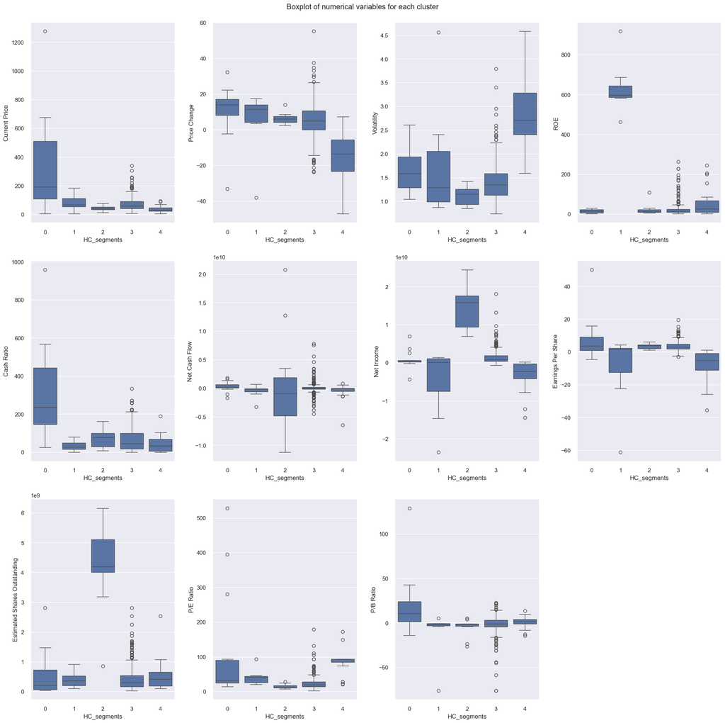

```python
plt.figure(figsize=(20, 20))
plt.suptitle("Boxplot of numerical variables for each cluster")

for i, variable in enumerate(num_col):
    plt.subplot(3, 4, i + 1)
    sns.boxplot(data=df2, x="HC_segments", y=variable)

plt.tight_layout(pad=2.0)
```

### We see that following:

** KMeans clustering with k=6

- Cluster 0: 14 companies
- Cluster 1: 37 companies
- Cluster 2: 6 companies
- Cluster 3: 5 companies
- Cluster 4: 9 companies
- Cluster 5: 269 companies

**Hierarchical Clustering: Distance=Euclidean; linkage=Ward with n_clusters=5**

- Cluster 0: 15 companies
- Cluster 1: 7 companies
- Cluster 2: 11 companies
- Cluster 3: 285 companies
- Cluster 4: 22 companies